# Project: Investigating Firearm Background Checks with U.S. Census Data

- Introduction
- Data Wrangling
- Exploratory Data Analysis
- Conclusions

## Introduction

In this analysis, I will be investigating firearm background checks against data from the United States Census. The data was obtained from Udacity's Data Analyst Nanodegree website. Further information for the firearm background checks can be found on the FBI National Instant Criminal Background Check (NICS) website at https://www.fbi.gov/services/cjis/nics. The data was originally in PDF form but has been converted to CSV file via the GitHub repository https://github.com/BuzzFeedNews/nics-firearm-background-checks/blob/master/README.md. The U.S. Census contains data from 2016 and can be found on the Census.gov website https://www.census.gov/.

According to the FBI NICS website:

```
"Mandated by the Brady Handgun Violence Prevention Act (Brady Act) of 1993, Public Law 103-159, the National Instant Criminal Background Check System (NICS) was established for Federal Firearms Licensees (FFLs) to contact by telephone, or other electronic means, for information to be supplied immediately on whether the transfer of a firearm would be in violation of Section 922 (g) or (n) of Title 18, United States Code, or state law. The Brady Act is a public record and is available from many sources, including the Internet at www.atf.gov."
```

The process of the NICS firearm background checks is as follows:

```
"When a person tries to buy a firearm, the seller, known as a Federal Firearms Licensee (FFL), contacts NICS electronically or by phone. The prospective buyer fills out the ATF form, and the FFL relays that information to the NICS. The NICS staff performs a background check on the buyer. That background check verifies the buyer does not have a criminal record or isn't otherwise ineligible to purchase or own a firearm"
```

The purpose of this analysis is to explore:

How many firearm background checks are performed by each ethnicity within the U.S.?

How many firearm background checks are performed by different education levels in the U.S.?

Is there a correlation between gun background checks compared to percent of people in poverty?

Which states have the highest growth of gun background checks within the data time period?

What is the overall trend of gun background checks thoughout the data time period?

It is important to note that the statistics within this chart represent the number of firearm background checks initiated through the NICS. They do not represent the number of firearms sold. Based on varying state laws and purchase scenarios, a one-to-one correlation cannot be made between a firearm background check and a firearm sale.

```python
import pandas as pd
import numpy as np
import datetime as dt
import matplotlib.pyplot as plt
% matplotlib inline
```

## Data Wrangling

### General Properties

```python
gun = pd.read_csv('gun_data.csv')
census = pd.read_csv('census_data.csv')
gun.head()
```

|  | month | state | permit | permit_recheck | handgun | long_gun | other | multiple | admin | prepawn_handgun | ... | returned_other | rentals_handgun | rentals_long_gun | private_sale_handgun | private_sale_long_gun | private_sale_other | return_to_seller_handgun | return_to_seller_long_gun | return_to_seller_other | totals |
| --- | --- | --- | --- | --- | --- | --- | --- | --- | --- | --- | --- | --- | --- | --- | --- | --- | --- | --- | --- | --- | --- |
| 0 | 2017-09 | Alabama | 16717.0 | 0.0 | 5734.0 | 6320.0 | 221.0 | 317 | 0.0 | 15.0 | ... | 0.0 | 0.0 | 0.0 | 9.0 | 16.0 | 3.0 | 0.0 | 0.0 | 3.0 | 32019 |
| 1 | 2017-09 | Alaska | 209.0 | 2.0 | 2320.0 | 2930.0 | 219.0 | 160 | 0.0 | 5.0 | ... | 0.0 | 0.0 | 0.0 | 17.0 | 24.0 | 1.0 | 0.0 | 0.0 | 0.0 | 6303 |
| 2 | 2017-09 | Arizona | 5069.0 | 382.0 | 11063.0 | 7946.0 | 920.0 | 631 | 0.0 | 13.0 | ... | 0.0 | 0.0 | 0.0 | 38.0 | 12.0 | 2.0 | 0.0 | 0.0 | 0.0 | 28394 |
| 3 | 2017-09 | Arkansas | 2935.0 | 632.0 | 4347.0 | 6063.0 | 165.0 | 366 | 51.0 | 12.0 | ... | 0.0 | 0.0 | 0.0 | 13.0 | 23.0 | 0.0 | 0.0 | 2.0 | 1.0 | 17747 |
| 4 | 2017-09 | California | 57839.0 | 0.0 | 37165.0 | 24581.0 | 2984.0 | 0 | 0.0 | 0.0 | ... | 0.0 | 0.0 | 0.0 | 0.0 | 0.0 | 0.0 | 0.0 | 0.0 | 0.0 | 123506 |

5 rows × 27 columns

The transactions types in the firearm dataset are unnecessary for the analyses that I'm performing. These will need to be dropped.

```python
gun.shape
```

```
(12485, 27)
```

I will only need three of these columns for my analyses.

```python
gun.info()
```

```
<class 'pandas.core.frame.DataFrame'>
RangeIndex: 12485 entries, 0 to 12484
Data columns (total 27 columns):
month                        12485 non-null object
state                        12485 non-null object
permit                       12461 non-null float64
permit_recheck               1100 non-null float64
handgun                      12465 non-null float64
long_gun                     12466 non-null float64
other                        5500 non-null float64
multiple                     12485 non-null int64
admin                        12462 non-null float64
prepawn_handgun              10542 non-null float64
prepawn_long_gun             10540 non-null float64
prepawn_other                5115 non-null float64
redemption_handgun           10545 non-null float64
redemption_long_gun          10544 non-null float64
redemption_other             5115 non-null float64
returned_handgun             2200 non-null float64
returned_long_gun            2145 non-null float64
returned_other               1815 non-null float64
rentals_handgun              990 non-null float64
rentals_long_gun             825 non-null float64
private_sale_handgun         2750 non-null float64
private_sale_long_gun        2750 non-null float64
private_sale_other           2750 non-null float64
return_to_seller_handgun     2475 non-null float64
return_to_seller_long_gun    2750 non-null float64
return_to_seller_other       2255 non-null float64
totals                       12485 non-null int64
dtypes: float64(23), int64(2), object(2)
memory usage: 2.6+ MB
```

There is missing data in the transaction columns, but these columns will be dropped before performing my analyses, so there is no need to change them.

```python
print(gun.duplicated().sum())
```

```
0
```

There is no duplicate data for the Gun dataset.

#### Now we'll explore the Census Data

```python
census.head(20)
```

|  | Fact | Fact Note | Alabama | Alaska | Arizona | Arkansas | California | Colorado | Connecticut | Delaware | ... | South Dakota | Tennessee | Texas | Utah | Vermont | Virginia | Washington | West Virginia | Wisconsin | Wyoming |
| --- | --- | --- | --- | --- | --- | --- | --- | --- | --- | --- | --- | --- | --- | --- | --- | --- | --- | --- | --- | --- | --- |
| 0 | Population estimates, July 1, 2016, (V2016) | NaN | 4,863,300 | 741,894 | 6,931,071 | 2,988,248 | 39,250,017 | 5,540,545 | 3,576,452 | 952,065 | ... | 865454 | 6651194 | 27,862,596 | 3,051,217 | 624,594 | 8,411,808 | 7,288,000 | 1,831,102 | 5,778,708 | 585,501 |
| 1 | Population estimates base, April 1, 2010, (V2... | NaN | 4,780,131 | 710,249 | 6,392,301 | 2,916,025 | 37,254,522 | 5,029,324 | 3,574,114 | 897,936 | ... | 814195 | 6346298 | 25,146,100 | 2,763,888 | 625,741 | 8,001,041 | 6,724,545 | 1,853,011 | 5,687,289 | 563,767 |
| 2 | Population, percent change - April 1, 2010 (es... | NaN | 1.70% | 4.50% | 8.40% | 2.50% | 5.40% | 10.20% | 0.10% | 6.00% | ... | 0.063 | 0.048 | 10.80% | 10.40% | -0.20% | 5.10% | 8.40% | -1.20% | 1.60% | 3.90% |
| 3 | Population, Census, April 1, 2010 | NaN | 4,779,736 | 710,231 | 6,392,017 | 2,915,918 | 37,253,956 | 5,029,196 | 3,574,097 | 897,934 | ... | 814180 | 6346105 | 25,145,561 | 2,763,885 | 625,741 | 8,001,024 | 6,724,540 | 1,852,994 | 5,686,986 | 563,626 |
| 4 | Persons under 5 years, percent, July 1, 2016, ... | NaN | 6.00% | 7.30% | 6.30% | 6.40% | 6.30% | 6.10% | 5.20% | 5.80% | ... | 0.071 | 0.061 | 7.20% | 8.30% | 4.90% | 6.10% | 6.20% | 5.50% | 5.80% | 6.50% |
| 5 | Persons under 5 years, percent, April 1, 2010 | NaN | 6.40% | 7.60% | 7.10% | 6.80% | 6.80% | 6.80% | 5.70% | 6.20% | ... | 0.073 | 0.064 | 7.70% | 9.50% | 5.10% | 6.40% | 6.50% | 5.60% | 6.30% | 7.10% |
| 6 | Persons under 18 years, percent, July 1, 2016,... | NaN | 22.60% | 25.20% | 23.50% | 23.60% | 23.20% | 22.80% | 21.10% | 21.50% | ... | 0.246 | 0.226 | 26.20% | 30.20% | 19.00% | 22.20% | 22.40% | 20.50% | 22.30% | 23.70% |
| 7 | Persons under 18 years, percent, April 1, 2010 | NaN | 23.70% | 26.40% | 25.50% | 24.40% | 25.00% | 24.40% | 22.90% | 22.90% | ... | 0.249 | 0.236 | 27.30% | 31.50% | 20.70% | 23.20% | 23.50% | 20.90% | 23.60% | 24.00% |
| 8 | Persons 65 years and over, percent, July 1, 2... | NaN | 16.10% | 10.40% | 16.90% | 16.30% | 13.60% | 13.40% | 16.10% | 17.50% | ... | 0.16 | 0.157 | 12.00% | 10.50% | 18.10% | 14.60% | 14.80% | 18.80% | 16.10% | 15.00% |
| 9 | Persons 65 years and over, percent, April 1, 2010 | NaN | 13.80% | 7.70% | 13.80% | 14.40% | 11.40% | 10.90% | 14.20% | 14.40% | ... | 0.143 | 0.134 | 10.30% | 9.00% | 14.60% | 12.20% | 12.30% | 16.00% | 13.70% | 12.40% |
| 10 | Female persons, percent, July 1, 2016, (V2016) | NaN | 51.60% | 47.70% | 50.30% | 50.90% | 50.30% | 49.70% | 51.20% | 51.60% | ... | 0.496 | 0.512 | 50.40% | 49.70% | 50.60% | 50.80% | 50.00% | 50.50% | 50.30% | 48.90% |
| 11 | Female persons, percent, April 1, 2010 | NaN | 51.50% | 48.00% | 50.30% | 50.90% | 50.30% | 49.90% | 51.30% | 51.60% | ... | 0.5 | 0.513 | 50.40% | 49.80% | 50.70% | 50.90% | 50.20% | 50.70% | 50.40% | 49.00% |
| 12 | White alone, percent, July 1, 2016, (V2016) | (a) | 69.30% | 66.10% | 83.30% | 79.40% | 72.70% | 87.50% | 80.60% | 70.10% | ... | 0.852 | 0.787 | 79.40% | 91.10% | 94.60% | 70.00% | 80.00% | 93.60% | 87.50% | 92.80% |
| 13 | Black or African American alone, percent, July... | (a) | 26.80% | 3.80% | 4.90% | 15.70% | 6.50% | 4.50% | 11.80% | 22.60% | ... | 0.02 | 0.171 | 12.60% | 1.40% | 1.30% | 19.80% | 4.10% | 3.60% | 6.60% | 1.30% |
| 14 | American Indian and Alaska Native alone, perce... | (a) | 0.70% | 15.20% | 5.40% | 1.00% | 1.70% | 1.60% | 0.50% | 0.60% | ... | 0.09 | 0.004 | 1.00% | 1.60% | 0.40% | 0.50% | 1.90% | 0.20% | 1.10% | 2.70% |
| 15 | Asian alone, percent, July 1, 2016, (V2016) | (a) | 1.40% | 6.30% | 3.40% | 1.60% | 14.80% | 3.30% | 4.70% | 4.00% | ... | 0.015 | 0.018 | 4.80% | 2.50% | 1.80% | 6.60% | 8.60% | 0.80% | 2.80% | 1.00% |
| 16 | Native Hawaiian and Other Pacific Islander alo... | (a) | 0.10% | 1.30% | 0.30% | 0.30% | 0.50% | 0.20% | 0.10% | 0.10% | ... | 0.001 | 0.001 | 0.10% | 1.00% | Z | 0.10% | 0.80% | Z | 0.10% | 0.10% |
| 17 | Two or More Races, percent, July 1, 2016, (V2... | NaN | 1.60% | 7.30% | 2.80% | 2.00% | 3.80% | 3.00% | 2.30% | 2.60% | ... | 0.023 | 0.019 | 1.90% | 2.50% | 1.90% | 2.90% | 4.60% | 1.70% | 1.90% | 2.10% |
| 18 | Hispanic or Latino, percent, July 1, 2016, (V... | (b) | 4.20% | 7.00% | 30.90% | 7.30% | 38.90% | 21.30% | 15.70% | 9.20% | ... | 0.037 | 0.052 | 39.10% | 13.80% | 1.90% | 9.10% | 12.40% | 1.50% | 6.70% | 10.00% |
| 19 | White alone, not Hispanic or Latino, percent, ... | NaN | 65.80% | 61.20% | 55.50% | 72.90% | 37.70% | 68.60% | 67.70% | 62.90% | ... | 0.825 | 0.742 | 42.60% | 78.80% | 93.10% | 62.40% | 69.50% | 92.30% | 81.70% | 84.10% |

20 rows × 52 columns

To make this dataset easier to analyse, I will transpose the rows and columns. The column headers will need to be formatted. Some of the proportions have a non numerical value of 'Z', which will need to converted to numerical format. Also, the proportions are in different formats (decimal and percentage) and will need to be converted to a uniform numerical format.

```python
census.info()
```

```
<class 'pandas.core.frame.DataFrame'>
RangeIndex: 85 entries, 0 to 84
Data columns (total 52 columns):
Fact              80 non-null object
Fact Note         28 non-null object
Alabama           65 non-null object
Alaska            65 non-null object
Arizona           65 non-null object
Arkansas          65 non-null object
California        65 non-null object
Colorado          65 non-null object
Connecticut       65 non-null object
Delaware          65 non-null object
Florida           65 non-null object
Georgia           65 non-null object
Hawaii            65 non-null object
Idaho             65 non-null object
Illinois          65 non-null object
Indiana           65 non-null object
Iowa              65 non-null object
Kansas            65 non-null object
Kentucky          65 non-null object
Louisiana         65 non-null object
Maine             65 non-null object
Maryland          65 non-null object
Massachusetts     65 non-null object
Michigan          65 non-null object
Minnesota         65 non-null object
Mississippi       65 non-null object
Missouri          65 non-null object
Montana           65 non-null object
Nebraska          65 non-null object
Nevada            65 non-null object
New Hampshire     65 non-null object
New Jersey        65 non-null object
New Mexico        65 non-null object
New York          65 non-null object
North Carolina    65 non-null object
North Dakota      65 non-null object
Ohio              65 non-null object
Oklahoma          65 non-null object
Oregon            65 non-null object
Pennsylvania      65 non-null object
Rhode Island      65 non-null object
South Carolina    65 non-null object
South Dakota      65 non-null object
Tennessee         65 non-null object
Texas             65 non-null object
Utah              65 non-null object
Vermont           65 non-null object
Virginia          65 non-null object
Washington        65 non-null object
West Virginia     65 non-null object
Wisconsin         65 non-null object
Wyoming           65 non-null object
dtypes: object(52)
memory usage: 34.6+ KB
```

```python
print(census.duplicated().sum())
```

```
3
```

There are three duplicate rows in the Census dataset.

```python
dups = census[census.duplicated()]
dups
```

|  | Fact | Fact Note | Alabama | Alaska | Arizona | Arkansas | California | Colorado | Connecticut | Delaware | ... | South Dakota | Tennessee | Texas | Utah | Vermont | Virginia | Washington | West Virginia | Wisconsin | Wyoming |
| --- | --- | --- | --- | --- | --- | --- | --- | --- | --- | --- | --- | --- | --- | --- | --- | --- | --- | --- | --- | --- | --- |
| 67 | NaN | NaN | NaN | NaN | NaN | NaN | NaN | NaN | NaN | NaN | ... | NaN | NaN | NaN | NaN | NaN | NaN | NaN | NaN | NaN | NaN |
| 70 | NaN | NaN | NaN | NaN | NaN | NaN | NaN | NaN | NaN | NaN | ... | NaN | NaN | NaN | NaN | NaN | NaN | NaN | NaN | NaN | NaN |
| 75 | NaN | NaN | NaN | NaN | NaN | NaN | NaN | NaN | NaN | NaN | ... | NaN | NaN | NaN | NaN | NaN | NaN | NaN | NaN | NaN | NaN |

3 rows × 52 columns

Duplicate rows of NaN values need to be dropped.

```python
census.drop_duplicates(inplace=True)
```

```python
print(census.duplicated().sum())
```

```
0
```

All duplicate data have been dropped from the Census dataframe.

### Data Cleaning: Formatting column names, changing datatypes, and dropping unnecessary data.

```python
gun.drop(gun.iloc[:, 2:26], inplace = True, axis = 1)
gun.head()
```

|  | month | state | totals |
| --- | --- | --- | --- |
| 0 | 2017-09 | Alabama | 32019 |
| 1 | 2017-09 | Alaska | 6303 |
| 2 | 2017-09 | Arizona | 28394 |
| 3 | 2017-09 | Arkansas | 17747 |
| 4 | 2017-09 | California | 123506 |

My analyses do not require the specific transaction type, so the transaction columns have been dropped.

```python
gun['year'] = pd.DatetimeIndex(gun['month']).year
gun['month_no'] = pd.DatetimeIndex(gun['month']).month
gun.head()
```

|  | month | state | totals | year | month_no |
| --- | --- | --- | --- | --- | --- |
| 0 | 2017-09 | Alabama | 32019 | 2017 | 9 |
| 1 | 2017-09 | Alaska | 6303 | 2017 | 9 |
| 2 | 2017-09 | Arizona | 28394 | 2017 | 9 |
| 3 | 2017-09 | Arkansas | 17747 | 2017 | 9 |
| 4 | 2017-09 | California | 123506 | 2017 | 9 |

I split the month column into separate month_no and year columns to make analysing easier.

```python
cols = list(gun.columns.values)
cols.pop(cols.index('year'))
cols.pop(cols.index('state'))
cols.pop(cols.index('totals'))
gun = gun[cols+['year','state','totals']]
gun.head()
```

|  | month | month_no | year | state | totals |
| --- | --- | --- | --- | --- | --- |
| 0 | 2017-09 | 9 | 2017 | Alabama | 32019 |
| 1 | 2017-09 | 9 | 2017 | Alaska | 6303 |
| 2 | 2017-09 | 9 | 2017 | Arizona | 28394 |
| 3 | 2017-09 | 9 | 2017 | Arkansas | 17747 |
| 4 | 2017-09 | 9 | 2017 | California | 123506 |

The columns have been reordered.

```python
gun = gun.drop(['month'], axis=1)
gun.head()
```

|  | month_no | year | state | totals |
| --- | --- | --- | --- | --- |
| 0 | 9 | 2017 | Alabama | 32019 |
| 1 | 9 | 2017 | Alaska | 6303 |
| 2 | 9 | 2017 | Arizona | 28394 |
| 3 | 9 | 2017 | Arkansas | 17747 |
| 4 | 9 | 2017 | California | 123506 |

The old month column has been dropped from the Gun dataset.

```python
gun.info()
```

```
<class 'pandas.core.frame.DataFrame'>
RangeIndex: 12485 entries, 0 to 12484
Data columns (total 4 columns):
month_no    12485 non-null int64
year        12485 non-null int64
state       12485 non-null object
totals      12485 non-null int64
dtypes: int64(3), object(1)
memory usage: 390.2+ KB
```

The datatypes for the columns are correct.

```python
gun_states = gun.groupby('state').totals.mean()
gun_states.shape
```

```
(55,)
```

The number of states in the Gun Dataset do not match the Census Dataset.

```python
gun = gun.drop(gun[gun.state.isin(['Guam', 'District of Columbia', 'Mariana Islands', 'Puerto Rico', 'Virgin Islands'])].index)
gun_states = gun.groupby('state').totals.mean()
gun_states.shape
```

```
(50,)
```

The datasets now have states that match

#### Now we'll clean up the Census Data

```python
census = census.T
census.head(50)
```

|  | 0 | 1 | 2 | 3 | 4 | 5 | 6 | 7 | 8 | 9 | ... | 74 | 76 | 77 | 78 | 79 | 80 | 81 | 82 | 83 | 84 |
| --- | --- | --- | --- | --- | --- | --- | --- | --- | --- | --- | --- | --- | --- | --- | --- | --- | --- | --- | --- | --- | --- |
| Fact | Population estimates, July 1, 2016, (V2016) | Population estimates base, April 1, 2010, (V2... | Population, percent change - April 1, 2010 (es... | Population, Census, April 1, 2010 | Persons under 5 years, percent, July 1, 2016, ... | Persons under 5 years, percent, April 1, 2010 | Persons under 18 years, percent, July 1, 2016,... | Persons under 18 years, percent, April 1, 2010 | Persons 65 years and over, percent, July 1, 2... | Persons 65 years and over, percent, April 1, 2010 | ... | (c) | Value Flags | - | D | F | FN | NaN | S | X | Z |
| Fact Note | NaN | NaN | NaN | NaN | NaN | NaN | NaN | NaN | NaN | NaN | ... | Economic Census - Puerto Rico data are not com... | NaN | Either no or too few sample observations were ... | Suppressed to avoid disclosure of confidential... | Fewer than 25 firms | Footnote on this item in place of data | Not available | Suppressed; does not meet publication standards | Not applicable | Value greater than zero but less than half uni... |
| Alabama | 4,863,300 | 4,780,131 | 1.70% | 4,779,736 | 6.00% | 6.40% | 22.60% | 23.70% | 16.10% | 13.80% | ... | NaN | NaN | NaN | NaN | NaN | NaN | NaN | NaN | NaN | NaN |
| Alaska | 741,894 | 710,249 | 4.50% | 710,231 | 7.30% | 7.60% | 25.20% | 26.40% | 10.40% | 7.70% | ... | NaN | NaN | NaN | NaN | NaN | NaN | NaN | NaN | NaN | NaN |
| Arizona | 6,931,071 | 6,392,301 | 8.40% | 6,392,017 | 6.30% | 7.10% | 23.50% | 25.50% | 16.90% | 13.80% | ... | NaN | NaN | NaN | NaN | NaN | NaN | NaN | NaN | NaN | NaN |
| Arkansas | 2,988,248 | 2,916,025 | 2.50% | 2,915,918 | 6.40% | 6.80% | 23.60% | 24.40% | 16.30% | 14.40% | ... | NaN | NaN | NaN | NaN | NaN | NaN | NaN | NaN | NaN | NaN |
| California | 39,250,017 | 37,254,522 | 5.40% | 37,253,956 | 6.30% | 6.80% | 23.20% | 25.00% | 13.60% | 11.40% | ... | NaN | NaN | NaN | NaN | NaN | NaN | NaN | NaN | NaN | NaN |
| Colorado | 5,540,545 | 5,029,324 | 10.20% | 5,029,196 | 6.10% | 6.80% | 22.80% | 24.40% | 13.40% | 10.90% | ... | NaN | NaN | NaN | NaN | NaN | NaN | NaN | NaN | NaN | NaN |
| Connecticut | 3,576,452 | 3,574,114 | 0.10% | 3,574,097 | 5.20% | 5.70% | 21.10% | 22.90% | 16.10% | 14.20% | ... | NaN | NaN | NaN | NaN | NaN | NaN | NaN | NaN | NaN | NaN |
| Delaware | 952,065 | 897,936 | 6.00% | 897,934 | 5.80% | 6.20% | 21.50% | 22.90% | 17.50% | 14.40% | ... | NaN | NaN | NaN | NaN | NaN | NaN | NaN | NaN | NaN | NaN |
| Florida | 20,612,439 | 18,804,592 | 9.60% | 18,801,310 | 5.50% | 5.70% | 20.10% | 21.30% | 19.90% | 17.30% | ... | NaN | NaN | NaN | NaN | NaN | NaN | NaN | NaN | NaN | NaN |
| Georgia | 10,310,371 | 9,688,680 | 6.40% | 9,687,653 | 6.40% | 7.10% | 24.40% | 25.70% | 13.10% | 10.70% | ... | NaN | NaN | NaN | NaN | NaN | NaN | NaN | NaN | NaN | NaN |
| Hawaii | 1,428,557 | 1,360,301 | 5.00% | 1,360,301 | 6.40% | 6.40% | 21.60% | 22.30% | 17.10% | 14.30% | ... | NaN | NaN | NaN | NaN | NaN | NaN | NaN | NaN | NaN | NaN |
| Idaho | 1,683,140 | 1,567,650 | 7.40% | 1,567,582 | 6.80% | 7.80% | 26.00% | 27.40% | 15.10% | 12.40% | ... | NaN | NaN | NaN | NaN | NaN | NaN | NaN | NaN | NaN | NaN |
| Illinois | 12,801,539 | 12,831,574 | -0.20% | 12,830,632 | 6.00% | 6.50% | 22.90% | 24.40% | 14.60% | 12.50% | ... | NaN | NaN | NaN | NaN | NaN | NaN | NaN | NaN | NaN | NaN |
| Indiana | 6,633,053 | 6,484,136 | 2.30% | 6,483,802 | 6.40% | 6.70% | 23.80% | 24.80% | 14.90% | 13.00% | ... | NaN | NaN | NaN | NaN | NaN | NaN | NaN | NaN | NaN | NaN |
| Iowa | 3,134,693 | 3,046,869 | 2.90% | 3,046,355 | 6.40% | 6.60% | 23.30% | 23.90% | 16.40% | 14.90% | ... | NaN | NaN | NaN | NaN | NaN | NaN | NaN | NaN | NaN | NaN |
| Kansas | 2,907,289 | 2,853,129 | 1.90% | 2,853,118 | 6.70% | 7.20% | 24.60% | 25.50% | 15.00% | 13.20% | ... | NaN | NaN | NaN | NaN | NaN | NaN | NaN | NaN | NaN | NaN |
| Kentucky | 4,436,974 | 4,339,344 | 2.20% | 4,339,367 | 6.20% | 6.50% | 22.80% | 23.60% | 15.60% | 13.30% | ... | NaN | NaN | NaN | NaN | NaN | NaN | NaN | NaN | NaN | NaN |
| Louisiana | 4,681,666 | 4,533,479 | 3.30% | 4,533,372 | 6.60% | 6.90% | 23.80% | 24.70% | 14.40% | 12.30% | ... | NaN | NaN | NaN | NaN | NaN | NaN | NaN | NaN | NaN | NaN |
| Maine | 1,331,479 | 1,328,364 | 0.20% | 1,328,361 | 4.90% | 5.20% | 19.10% | 20.70% | 19.40% | 15.90% | ... | NaN | NaN | NaN | NaN | NaN | NaN | NaN | NaN | NaN | NaN |
| Maryland | 6,016,447 | 5,773,786 | 4.20% | 5,773,552 | 6.10% | 6.30% | 22.40% | 23.40% | 14.60% | 12.30% | ... | NaN | NaN | NaN | NaN | NaN | NaN | NaN | NaN | NaN | NaN |
| Massachusetts | 6,811,779 | 6,547,813 | 4.00% | 6,547,629 | 5.30% | 5.60% | 20.20% | 21.70% | 15.80% | 13.80% | ... | NaN | NaN | NaN | NaN | NaN | NaN | NaN | NaN | NaN | NaN |
| Michigan | 9,928,300 | 9,884,129 | 0.40% | 9,883,640 | 5.80% | 6.00% | 22.10% | 23.70% | 16.20% | 13.80% | ... | NaN | NaN | NaN | NaN | NaN | NaN | NaN | NaN | NaN | NaN |
| Minnesota | 5,519,952 | 5,303,924 | 4.10% | 5,303,925 | 6.40% | 6.70% | 23.30% | 24.20% | 15.10% | 12.90% | ... | NaN | NaN | NaN | NaN | NaN | NaN | NaN | NaN | NaN | NaN |
| Mississippi | 2,988,726 | 2,968,103 | 0.70% | 2,967,297 | 6.30% | 7.10% | 24.10% | 25.50% | 15.10% | 12.80% | ... | NaN | NaN | NaN | NaN | NaN | NaN | NaN | NaN | NaN | NaN |
| Missouri | 6,093,000 | 5,988,928 | 1.70% | 5,988,927 | 6.10% | 6.50% | 22.80% | 23.80% | 16.10% | 14.00% | ... | NaN | NaN | NaN | NaN | NaN | NaN | NaN | NaN | NaN | NaN |
| Montana | 1,042,520 | 989,414 | 5.40% | 989,415 | 6.00% | 6.30% | 21.80% | 22.60% | 17.70% | 14.80% | ... | NaN | NaN | NaN | NaN | NaN | NaN | NaN | NaN | NaN | NaN |
| Nebraska | 1,907,116 | 1,826,334 | 4.40% | 1,826,341 | 7.00% | 7.20% | 24.80% | 25.10% | 15.00% | 13.50% | ... | NaN | NaN | NaN | NaN | NaN | NaN | NaN | NaN | NaN | NaN |
| Nevada | 2,940,058 | 2,700,691 | 8.90% | 2,700,551 | 6.30% | 6.90% | 23.00% | 24.60% | 15.00% | 12.00% | ... | NaN | NaN | NaN | NaN | NaN | NaN | NaN | NaN | NaN | NaN |
| New Hampshire | 1,334,795 | 1,316,461 | 1.40% | 1,316,470 | 4.80% | 5.30% | 19.50% | 21.80% | 17.00% | 13.50% | ... | NaN | NaN | NaN | NaN | NaN | NaN | NaN | NaN | NaN | NaN |
| New Jersey | 8,944,469 | 8,791,953 | 1.70% | 8,791,894 | 5.80% | 6.20% | 22.20% | 23.50% | 15.30% | 13.50% | ... | NaN | NaN | NaN | NaN | NaN | NaN | NaN | NaN | NaN | NaN |
| New Mexico | 2081015 | 2059198 | 0.011 | 2059179 | 0.062 | 0.07 | 0.236 | 0.252 | 0.165 | 0.132 | ... | NaN | NaN | NaN | NaN | NaN | NaN | NaN | NaN | NaN | NaN |
| New York | 19745289 | 19378110 | 0.019 | 19378102 | 0.059 | 0.06 | 0.212 | 0.223 | 0.154 | 0.135 | ... | NaN | NaN | NaN | NaN | NaN | NaN | NaN | NaN | NaN | NaN |
| North Carolina | 10146788 | 9535688 | 0.064 | 9535483 | 0.06 | 0.066 | 0.227 | 0.239 | 0.155 | 0.129 | ... | NaN | NaN | NaN | NaN | NaN | NaN | NaN | NaN | NaN | NaN |
| North Dakota | 757952 | 672591 | 0.127 | 672591 | 0.073 | 0.066 | 0.233 | 0.223 | 0.145 | 0.145 | ... | NaN | NaN | NaN | NaN | NaN | NaN | NaN | NaN | NaN | NaN |
| Ohio | 11614373 | 11536727 | 0.007 | 11536504 | 0.06 | 0.062 | 0.225 | 0.237 | 0.162 | 0.141 | ... | NaN | NaN | NaN | NaN | NaN | NaN | NaN | NaN | NaN | NaN |
| Oklahoma | 3923561 | 3751615 | 0.046 | 3751351 | 0.068 | 0.07 | 0.245 | 0.248 | 0.15 | 0.135 | ... | NaN | NaN | NaN | NaN | NaN | NaN | NaN | NaN | NaN | NaN |
| Oregon | 4093465 | 3831072 | 0.068 | 3831074 | 0.058 | 0.062 | 0.212 | 0.226 | 0.168 | 0.139 | ... | NaN | NaN | NaN | NaN | NaN | NaN | NaN | NaN | NaN | NaN |
| Pennsylvania | 12784227 | 12702857 | 0.006 | 12702379 | 0.056 | 0.057 | 0.209 | 0.22 | 0.174 | 0.154 | ... | NaN | NaN | NaN | NaN | NaN | NaN | NaN | NaN | NaN | NaN |
| Rhode Island | 1056426 | 1052940 | 0.003 | 1052567 | 0.052 | 0.055 | 0.197 | 0.213 | 0.165 | 0.144 | ... | NaN | NaN | NaN | NaN | NaN | NaN | NaN | NaN | NaN | NaN |
| South Carolina | 4961119 | 4625410 | 0.073 | 4625364 | 0.059 | 0.065 | 0.221 | 0.234 | 0.167 | 0.137 | ... | NaN | NaN | NaN | NaN | NaN | NaN | NaN | NaN | NaN | NaN |
| South Dakota | 865454 | 814195 | 0.063 | 814180 | 0.071 | 0.073 | 0.246 | 0.249 | 0.16 | 0.143 | ... | NaN | NaN | NaN | NaN | NaN | NaN | NaN | NaN | NaN | NaN |
| Tennessee | 6651194 | 6346298 | 0.048 | 6346105 | 0.061 | 0.064 | 0.226 | 0.236 | 0.157 | 0.134 | ... | NaN | NaN | NaN | NaN | NaN | NaN | NaN | NaN | NaN | NaN |
| Texas | 27,862,596 | 25,146,100 | 10.80% | 25,145,561 | 7.20% | 7.70% | 26.20% | 27.30% | 12.00% | 10.30% | ... | NaN | NaN | NaN | NaN | NaN | NaN | NaN | NaN | NaN | NaN |
| Utah | 3,051,217 | 2,763,888 | 10.40% | 2,763,885 | 8.30% | 9.50% | 30.20% | 31.50% | 10.50% | 9.00% | ... | NaN | NaN | NaN | NaN | NaN | NaN | NaN | NaN | NaN | NaN |
| Vermont | 624,594 | 625,741 | -0.20% | 625,741 | 4.90% | 5.10% | 19.00% | 20.70% | 18.10% | 14.60% | ... | NaN | NaN | NaN | NaN | NaN | NaN | NaN | NaN | NaN | NaN |
| Virginia | 8,411,808 | 8,001,041 | 5.10% | 8,001,024 | 6.10% | 6.40% | 22.20% | 23.20% | 14.60% | 12.20% | ... | NaN | NaN | NaN | NaN | NaN | NaN | NaN | NaN | NaN | NaN |
| Washington | 7,288,000 | 6,724,545 | 8.40% | 6,724,540 | 6.20% | 6.50% | 22.40% | 23.50% | 14.80% | 12.30% | ... | NaN | NaN | NaN | NaN | NaN | NaN | NaN | NaN | NaN | NaN |
| West Virginia | 1,831,102 | 1,853,011 | -1.20% | 1,852,994 | 5.50% | 5.60% | 20.50% | 20.90% | 18.80% | 16.00% | ... | NaN | NaN | NaN | NaN | NaN | NaN | NaN | NaN | NaN | NaN |

50 rows × 82 columns

The dataset was transposed to make it easier for cleaning and analysis.

```python
census.columns = census.iloc[0]
census.head()
```

| Fact | Population estimates, July 1, 2016, (V2016) | Population estimates base, April 1, 2010, (V2016) | Population, percent change - April 1, 2010 (estimates base) to July 1, 2016, (V2016) | Population, Census, April 1, 2010 | Persons under 5 years, percent, July 1, 2016, (V2016) | Persons under 5 years, percent, April 1, 2010 | Persons under 18 years, percent, July 1, 2016, (V2016) | Persons under 18 years, percent, April 1, 2010 | Persons 65 years and over, percent, July 1, 2016, (V2016) | Persons 65 years and over, percent, April 1, 2010 | ... | (c) | Value Flags | - | D | F | FN | nan | S | X | Z |
| --- | --- | --- | --- | --- | --- | --- | --- | --- | --- | --- | --- | --- | --- | --- | --- | --- | --- | --- | --- | --- | --- |
| Fact | Population estimates, July 1, 2016, (V2016) | Population estimates base, April 1, 2010, (V2... | Population, percent change - April 1, 2010 (es... | Population, Census, April 1, 2010 | Persons under 5 years, percent, July 1, 2016, ... | Persons under 5 years, percent, April 1, 2010 | Persons under 18 years, percent, July 1, 2016,... | Persons under 18 years, percent, April 1, 2010 | Persons 65 years and over, percent, July 1, 2... | Persons 65 years and over, percent, April 1, 2010 | ... | (c) | Value Flags | - | D | F | FN | NaN | S | X | Z |
| Fact Note | NaN | NaN | NaN | NaN | NaN | NaN | NaN | NaN | NaN | NaN | ... | Economic Census - Puerto Rico data are not com... | NaN | Either no or too few sample observations were ... | Suppressed to avoid disclosure of confidential... | Fewer than 25 firms | Footnote on this item in place of data | Not available | Suppressed; does not meet publication standards | Not applicable | Value greater than zero but less than half uni... |
| Alabama | 4,863,300 | 4,780,131 | 1.70% | 4,779,736 | 6.00% | 6.40% | 22.60% | 23.70% | 16.10% | 13.80% | ... | NaN | NaN | NaN | NaN | NaN | NaN | NaN | NaN | NaN | NaN |
| Alaska | 741,894 | 710,249 | 4.50% | 710,231 | 7.30% | 7.60% | 25.20% | 26.40% | 10.40% | 7.70% | ... | NaN | NaN | NaN | NaN | NaN | NaN | NaN | NaN | NaN | NaN |
| Arizona | 6,931,071 | 6,392,301 | 8.40% | 6,392,017 | 6.30% | 7.10% | 23.50% | 25.50% | 16.90% | 13.80% | ... | NaN | NaN | NaN | NaN | NaN | NaN | NaN | NaN | NaN | NaN |

5 rows × 82 columns

The index numbers were replaced by the first row as the column headers.

```python
census= census.drop(census.index[0:2])
census.head()
```

| Fact | Population estimates, July 1, 2016, (V2016) | Population estimates base, April 1, 2010, (V2016) | Population, percent change - April 1, 2010 (estimates base) to July 1, 2016, (V2016) | Population, Census, April 1, 2010 | Persons under 5 years, percent, July 1, 2016, (V2016) | Persons under 5 years, percent, April 1, 2010 | Persons under 18 years, percent, July 1, 2016, (V2016) | Persons under 18 years, percent, April 1, 2010 | Persons 65 years and over, percent, July 1, 2016, (V2016) | Persons 65 years and over, percent, April 1, 2010 | ... | (c) | Value Flags | - | D | F | FN | nan | S | X | Z |
| --- | --- | --- | --- | --- | --- | --- | --- | --- | --- | --- | --- | --- | --- | --- | --- | --- | --- | --- | --- | --- | --- |
| Alabama | 4,863,300 | 4,780,131 | 1.70% | 4,779,736 | 6.00% | 6.40% | 22.60% | 23.70% | 16.10% | 13.80% | ... | NaN | NaN | NaN | NaN | NaN | NaN | NaN | NaN | NaN | NaN |
| Alaska | 741,894 | 710,249 | 4.50% | 710,231 | 7.30% | 7.60% | 25.20% | 26.40% | 10.40% | 7.70% | ... | NaN | NaN | NaN | NaN | NaN | NaN | NaN | NaN | NaN | NaN |
| Arizona | 6,931,071 | 6,392,301 | 8.40% | 6,392,017 | 6.30% | 7.10% | 23.50% | 25.50% | 16.90% | 13.80% | ... | NaN | NaN | NaN | NaN | NaN | NaN | NaN | NaN | NaN | NaN |
| Arkansas | 2,988,248 | 2,916,025 | 2.50% | 2,915,918 | 6.40% | 6.80% | 23.60% | 24.40% | 16.30% | 14.40% | ... | NaN | NaN | NaN | NaN | NaN | NaN | NaN | NaN | NaN | NaN |
| California | 39,250,017 | 37,254,522 | 5.40% | 37,253,956 | 6.30% | 6.80% | 23.20% | 25.00% | 13.60% | 11.40% | ... | NaN | NaN | NaN | NaN | NaN | NaN | NaN | NaN | NaN | NaN |

5 rows × 82 columns

The first two rows were unnecessary and dropped.

```python
census.reset_index(drop = False, inplace = True)
census.head()
```

| Fact | index | Population estimates, July 1, 2016, (V2016) | Population estimates base, April 1, 2010, (V2016) | Population, percent change - April 1, 2010 (estimates base) to July 1, 2016, (V2016) | Population, Census, April 1, 2010 | Persons under 5 years, percent, July 1, 2016, (V2016) | Persons under 5 years, percent, April 1, 2010 | Persons under 18 years, percent, July 1, 2016, (V2016) | Persons under 18 years, percent, April 1, 2010 | Persons 65 years and over, percent, July 1, 2016, (V2016) | ... | (c) | Value Flags | - | D | F | FN | nan | S | X | Z |
| --- | --- | --- | --- | --- | --- | --- | --- | --- | --- | --- | --- | --- | --- | --- | --- | --- | --- | --- | --- | --- | --- |
| 0 | Alabama | 4,863,300 | 4,780,131 | 1.70% | 4,779,736 | 6.00% | 6.40% | 22.60% | 23.70% | 16.10% | ... | NaN | NaN | NaN | NaN | NaN | NaN | NaN | NaN | NaN | NaN |
| 1 | Alaska | 741,894 | 710,249 | 4.50% | 710,231 | 7.30% | 7.60% | 25.20% | 26.40% | 10.40% | ... | NaN | NaN | NaN | NaN | NaN | NaN | NaN | NaN | NaN | NaN |
| 2 | Arizona | 6,931,071 | 6,392,301 | 8.40% | 6,392,017 | 6.30% | 7.10% | 23.50% | 25.50% | 16.90% | ... | NaN | NaN | NaN | NaN | NaN | NaN | NaN | NaN | NaN | NaN |
| 3 | Arkansas | 2,988,248 | 2,916,025 | 2.50% | 2,915,918 | 6.40% | 6.80% | 23.60% | 24.40% | 16.30% | ... | NaN | NaN | NaN | NaN | NaN | NaN | NaN | NaN | NaN | NaN |
| 4 | California | 39,250,017 | 37,254,522 | 5.40% | 37,253,956 | 6.30% | 6.80% | 23.20% | 25.00% | 13.60% | ... | NaN | NaN | NaN | NaN | NaN | NaN | NaN | NaN | NaN | NaN |

5 rows × 83 columns

Index numbers were reset for the rows.

```python
census = census.rename_axis(None, axis=1)
census.head()
```

|  | index | Population estimates, July 1, 2016, (V2016) | Population estimates base, April 1, 2010, (V2016) | Population, percent change - April 1, 2010 (estimates base) to July 1, 2016, (V2016) | Population, Census, April 1, 2010 | Persons under 5 years, percent, July 1, 2016, (V2016) | Persons under 5 years, percent, April 1, 2010 | Persons under 18 years, percent, July 1, 2016, (V2016) | Persons under 18 years, percent, April 1, 2010 | Persons 65 years and over, percent, July 1, 2016, (V2016) | ... | (c) | Value Flags | - | D | F | FN | nan | S | X | Z |
| --- | --- | --- | --- | --- | --- | --- | --- | --- | --- | --- | --- | --- | --- | --- | --- | --- | --- | --- | --- | --- | --- |
| 0 | Alabama | 4,863,300 | 4,780,131 | 1.70% | 4,779,736 | 6.00% | 6.40% | 22.60% | 23.70% | 16.10% | ... | NaN | NaN | NaN | NaN | NaN | NaN | NaN | NaN | NaN | NaN |
| 1 | Alaska | 741,894 | 710,249 | 4.50% | 710,231 | 7.30% | 7.60% | 25.20% | 26.40% | 10.40% | ... | NaN | NaN | NaN | NaN | NaN | NaN | NaN | NaN | NaN | NaN |
| 2 | Arizona | 6,931,071 | 6,392,301 | 8.40% | 6,392,017 | 6.30% | 7.10% | 23.50% | 25.50% | 16.90% | ... | NaN | NaN | NaN | NaN | NaN | NaN | NaN | NaN | NaN | NaN |
| 3 | Arkansas | 2,988,248 | 2,916,025 | 2.50% | 2,915,918 | 6.40% | 6.80% | 23.60% | 24.40% | 16.30% | ... | NaN | NaN | NaN | NaN | NaN | NaN | NaN | NaN | NaN | NaN |
| 4 | California | 39,250,017 | 37,254,522 | 5.40% | 37,253,956 | 6.30% | 6.80% | 23.20% | 25.00% | 13.60% | ... | NaN | NaN | NaN | NaN | NaN | NaN | NaN | NaN | NaN | NaN |

5 rows × 83 columns

The index row name 'Fact' was removed.

```python
census = census.rename(columns = {'index':'State'})
census.head()
```

|  | State | Population estimates, July 1, 2016, (V2016) | Population estimates base, April 1, 2010, (V2016) | Population, percent change - April 1, 2010 (estimates base) to July 1, 2016, (V2016) | Population, Census, April 1, 2010 | Persons under 5 years, percent, July 1, 2016, (V2016) | Persons under 5 years, percent, April 1, 2010 | Persons under 18 years, percent, July 1, 2016, (V2016) | Persons under 18 years, percent, April 1, 2010 | Persons 65 years and over, percent, July 1, 2016, (V2016) | ... | (c) | Value Flags | - | D | F | FN | nan | S | X | Z |
| --- | --- | --- | --- | --- | --- | --- | --- | --- | --- | --- | --- | --- | --- | --- | --- | --- | --- | --- | --- | --- | --- |
| 0 | Alabama | 4,863,300 | 4,780,131 | 1.70% | 4,779,736 | 6.00% | 6.40% | 22.60% | 23.70% | 16.10% | ... | NaN | NaN | NaN | NaN | NaN | NaN | NaN | NaN | NaN | NaN |
| 1 | Alaska | 741,894 | 710,249 | 4.50% | 710,231 | 7.30% | 7.60% | 25.20% | 26.40% | 10.40% | ... | NaN | NaN | NaN | NaN | NaN | NaN | NaN | NaN | NaN | NaN |
| 2 | Arizona | 6,931,071 | 6,392,301 | 8.40% | 6,392,017 | 6.30% | 7.10% | 23.50% | 25.50% | 16.90% | ... | NaN | NaN | NaN | NaN | NaN | NaN | NaN | NaN | NaN | NaN |
| 3 | Arkansas | 2,988,248 | 2,916,025 | 2.50% | 2,915,918 | 6.40% | 6.80% | 23.60% | 24.40% | 16.30% | ... | NaN | NaN | NaN | NaN | NaN | NaN | NaN | NaN | NaN | NaN |
| 4 | California | 39,250,017 | 37,254,522 | 5.40% | 37,253,956 | 6.30% | 6.80% | 23.20% | 25.00% | 13.60% | ... | NaN | NaN | NaN | NaN | NaN | NaN | NaN | NaN | NaN | NaN |

5 rows × 83 columns

The column labeled as index was renamed 'State'.

```python
for i, v in enumerate(census.columns):
    print(i,v)
```

```
0 State
1 Population estimates, July 1, 2016,  (V2016)
2 Population estimates base, April 1, 2010,  (V2016)
3 Population, percent change - April 1, 2010 (estimates base) to July 1, 2016,  (V2016)
4 Population, Census, April 1, 2010
5 Persons under 5 years, percent, July 1, 2016,  (V2016)
6 Persons under 5 years, percent, April 1, 2010
7 Persons under 18 years, percent, July 1, 2016,  (V2016)
8 Persons under 18 years, percent, April 1, 2010
9 Persons 65 years and over, percent,  July 1, 2016,  (V2016)
10 Persons 65 years and over, percent, April 1, 2010
11 Female persons, percent,  July 1, 2016,  (V2016)
12 Female persons, percent, April 1, 2010
13 White alone, percent, July 1, 2016,  (V2016)
14 Black or African American alone, percent, July 1, 2016,  (V2016)
```

[output cut: 68 more lines]

Checking to see which column index numbers I need for my analyses.

```python
census = census.iloc[:, np.r_[0,1, 13:21, 35:37, 50]]
census.head()
```

|  | State | Population estimates, July 1, 2016, (V2016) | White alone, percent, July 1, 2016, (V2016) | Black or African American alone, percent, July 1, 2016, (V2016) | American Indian and Alaska Native alone, percent, July 1, 2016, (V2016) | Asian alone, percent, July 1, 2016, (V2016) | Native Hawaiian and Other Pacific Islander alone, percent, July 1, 2016, (V2016) | Two or More Races, percent, July 1, 2016, (V2016) | Hispanic or Latino, percent, July 1, 2016, (V2016) | White alone, not Hispanic or Latino, percent, July 1, 2016, (V2016) | High school graduate or higher, percent of persons age 25 years+, 2011-2015 | Bachelor's degree or higher, percent of persons age 25 years+, 2011-2015 | Persons in poverty, percent |
| --- | --- | --- | --- | --- | --- | --- | --- | --- | --- | --- | --- | --- | --- |
| 0 | Alabama | 4,863,300 | 69.30% | 26.80% | 0.70% | 1.40% | 0.10% | 1.60% | 4.20% | 65.80% | 84.30% | 23.50% | 17.10% |
| 1 | Alaska | 741,894 | 66.10% | 3.80% | 15.20% | 6.30% | 1.30% | 7.30% | 7.00% | 61.20% | 92.10% | 28.00% | 9.90% |
| 2 | Arizona | 6,931,071 | 83.30% | 4.90% | 5.40% | 3.40% | 0.30% | 2.80% | 30.90% | 55.50% | 86.00% | 27.50% | 16.40% |
| 3 | Arkansas | 2,988,248 | 79.40% | 15.70% | 1.00% | 1.60% | 0.30% | 2.00% | 7.30% | 72.90% | 84.80% | 21.10% | 17.20% |
| 4 | California | 39,250,017 | 72.70% | 6.50% | 1.70% | 14.80% | 0.50% | 3.80% | 38.90% | 37.70% | 81.80% | 31.40% | 14.30% |

Unnecessary columns were filtered out.

```python
census.columns = census.columns.str.split(',').str[0]
census.head()
```

|  | State | Population estimates | White alone | Black or African American alone | American Indian and Alaska Native alone | Asian alone | Native Hawaiian and Other Pacific Islander alone | Two or More Races | Hispanic or Latino | White alone | High school graduate or higher | Bachelor's degree or higher | Persons in poverty |
| --- | --- | --- | --- | --- | --- | --- | --- | --- | --- | --- | --- | --- | --- |
| 0 | Alabama | 4,863,300 | 69.30% | 26.80% | 0.70% | 1.40% | 0.10% | 1.60% | 4.20% | 65.80% | 84.30% | 23.50% | 17.10% |
| 1 | Alaska | 741,894 | 66.10% | 3.80% | 15.20% | 6.30% | 1.30% | 7.30% | 7.00% | 61.20% | 92.10% | 28.00% | 9.90% |
| 2 | Arizona | 6,931,071 | 83.30% | 4.90% | 5.40% | 3.40% | 0.30% | 2.80% | 30.90% | 55.50% | 86.00% | 27.50% | 16.40% |
| 3 | Arkansas | 2,988,248 | 79.40% | 15.70% | 1.00% | 1.60% | 0.30% | 2.00% | 7.30% | 72.90% | 84.80% | 21.10% | 17.20% |
| 4 | California | 39,250,017 | 72.70% | 6.50% | 1.70% | 14.80% | 0.50% | 3.80% | 38.90% | 37.70% | 81.80% | 31.40% | 14.30% |

Unnecessary characters were removed and the column names were shortened.

```python
census.columns.values[[2, 9]] = ['White alone', 'White alone non hispanic']
census.head()
```

|  | State | Population estimates | White alone | Black or African American alone | American Indian and Alaska Native alone | Asian alone | Native Hawaiian and Other Pacific Islander alone | Two or More Races | Hispanic or Latino | White alone non hispanic | High school graduate or higher | Bachelor's degree or higher | Persons in poverty |
| --- | --- | --- | --- | --- | --- | --- | --- | --- | --- | --- | --- | --- | --- |
| 0 | Alabama | 4,863,300 | 69.30% | 26.80% | 0.70% | 1.40% | 0.10% | 1.60% | 4.20% | 65.80% | 84.30% | 23.50% | 17.10% |
| 1 | Alaska | 741,894 | 66.10% | 3.80% | 15.20% | 6.30% | 1.30% | 7.30% | 7.00% | 61.20% | 92.10% | 28.00% | 9.90% |
| 2 | Arizona | 6,931,071 | 83.30% | 4.90% | 5.40% | 3.40% | 0.30% | 2.80% | 30.90% | 55.50% | 86.00% | 27.50% | 16.40% |
| 3 | Arkansas | 2,988,248 | 79.40% | 15.70% | 1.00% | 1.60% | 0.30% | 2.00% | 7.30% | 72.90% | 84.80% | 21.10% | 17.20% |
| 4 | California | 39,250,017 | 72.70% | 6.50% | 1.70% | 14.80% | 0.50% | 3.80% | 38.90% | 37.70% | 81.80% | 31.40% | 14.30% |

After the column names were split, it produced two columns with the same name, so I renamed "White alone non Hispanic", insead of "White alone". These will be combined and averaged at the end of the data cleaning.

```python
census.columns = census.columns.str.strip().str.lower().str.replace(' ', '_')
census.head()
```

|  | state | population_estimates | white_alone | black_or_african_american_alone | american_indian_and_alaska_native_alone | asian_alone | native_hawaiian_and_other_pacific_islander_alone | two_or_more_races | hispanic_or_latino | white_alone_non_hispanic | high_school_graduate_or_higher | bachelor's_degree_or_higher | persons_in_poverty |
| --- | --- | --- | --- | --- | --- | --- | --- | --- | --- | --- | --- | --- | --- |
| 0 | Alabama | 4,863,300 | 69.30% | 26.80% | 0.70% | 1.40% | 0.10% | 1.60% | 4.20% | 65.80% | 84.30% | 23.50% | 17.10% |
| 1 | Alaska | 741,894 | 66.10% | 3.80% | 15.20% | 6.30% | 1.30% | 7.30% | 7.00% | 61.20% | 92.10% | 28.00% | 9.90% |
| 2 | Arizona | 6,931,071 | 83.30% | 4.90% | 5.40% | 3.40% | 0.30% | 2.80% | 30.90% | 55.50% | 86.00% | 27.50% | 16.40% |
| 3 | Arkansas | 2,988,248 | 79.40% | 15.70% | 1.00% | 1.60% | 0.30% | 2.00% | 7.30% | 72.90% | 84.80% | 21.10% | 17.20% |
| 4 | California | 39,250,017 | 72.70% | 6.50% | 1.70% | 14.80% | 0.50% | 3.80% | 38.90% | 37.70% | 81.80% | 31.40% | 14.30% |

The column names were formatted into lower case with no spaces.

```python
census.apply(lambda column: column.astype(str).str.contains('Z').any(), axis=0)
```

```
state                                               False
population_estimates                                False
white_alone                                         False
black_or_african_american_alone                     False
american_indian_and_alaska_native_alone             False
asian_alone                                         False
native_hawaiian_and_other_pacific_islander_alone     True
two_or_more_races                                   False
hispanic_or_latino                                  False
white_alone_non_hispanic                            False
high_school_graduate_or_higher                      False
bachelor's_degree_or_higher                         False
persons_in_poverty                                  False
dtype: bool
```

The column that contains the string 'Z' has been identified.

```python
census['native_hawaiian_and_other_pacific_islander_alone']
```

```
0      0.10%
1      1.30%
2      0.30%
3      0.30%
4      0.50%
5      0.20%
6      0.10%
7      0.10%
8      0.10%
9      0.10%
10    10.20%
11     0.20%
12     0.10%
13     0.10%
14     0.10%
```

[output cut: 36 more lines]

The native hawaiian column contains 4 instances of the string 'Z'.

```python
census = census.replace(to_replace = "Z", value = '0.0%')
census['native_hawaiian_and_other_pacific_islander_alone']
```

```
0      0.10%
1      1.30%
2      0.30%
3      0.30%
4      0.50%
5      0.20%
6      0.10%
7      0.10%
8      0.10%
9      0.10%
10    10.20%
11     0.20%
12     0.10%
13     0.10%
14     0.10%
```

[output cut: 36 more lines]

According to the Census Data, the value 'Z' means that the value is greater than zero but less than half unit of measure shown. I converted 'Z' to a 0.0% (str) and will then convert all strings to numeric formats.

```python
census.apply(lambda column: column.astype(str).str.contains('Z').any(), axis=0)
```

```
state                                               False
population_estimates                                False
white_alone                                         False
black_or_african_american_alone                     False
american_indian_and_alaska_native_alone             False
asian_alone                                         False
native_hawaiian_and_other_pacific_islander_alone    False
two_or_more_races                                   False
hispanic_or_latino                                  False
white_alone_non_hispanic                            False
high_school_graduate_or_higher                      False
bachelor's_degree_or_higher                         False
persons_in_poverty                                  False
dtype: bool
```

All strings of 'Z' have been replaced.

```python
census.info()
```

```
<class 'pandas.core.frame.DataFrame'>
RangeIndex: 50 entries, 0 to 49
Data columns (total 13 columns):
state                                               50 non-null object
population_estimates                                50 non-null object
white_alone                                         50 non-null object
black_or_african_american_alone                     50 non-null object
american_indian_and_alaska_native_alone             50 non-null object
asian_alone                                         50 non-null object
native_hawaiian_and_other_pacific_islander_alone    50 non-null object
two_or_more_races                                   50 non-null object
hispanic_or_latino                                  50 non-null object
white_alone_non_hispanic                            50 non-null object
high_school_graduate_or_higher                      50 non-null object
bachelor's_degree_or_higher                         50 non-null object
persons_in_poverty                                  50 non-null object
dtypes: object(13)
memory usage: 5.2+ KB
```

The columns of the ethnicity, type of degree, and poverty levels need to be converted from strings to floats.

```python
census.applymap(lambda x: '%' in str(x))
```

|  | state | population_estimates | white_alone | black_or_african_american_alone | american_indian_and_alaska_native_alone | asian_alone | native_hawaiian_and_other_pacific_islander_alone | two_or_more_races | hispanic_or_latino | white_alone_non_hispanic | high_school_graduate_or_higher | bachelor's_degree_or_higher | persons_in_poverty |
| --- | --- | --- | --- | --- | --- | --- | --- | --- | --- | --- | --- | --- | --- |
| 0 | False | False | True | True | True | True | True | True | True | True | True | True | True |
| 1 | False | False | True | True | True | True | True | True | True | True | True | True | True |
| 2 | False | False | True | True | True | True | True | True | True | True | True | True | True |
| 3 | False | False | True | True | True | True | True | True | True | True | True | True | True |
| 4 | False | False | True | True | True | True | True | True | True | True | True | True | True |
| 5 | False | False | True | True | True | True | True | True | True | True | True | True | True |
| 6 | False | False | True | True | True | True | True | True | True | True | True | True | True |
| 7 | False | False | True | True | True | True | True | True | True | True | True | True | True |
| 8 | False | False | True | True | True | True | True | True | True | True | True | True | True |
| 9 | False | False | True | True | True | True | True | True | True | True | True | True | True |
| 10 | False | False | True | True | True | True | True | True | True | True | True | True | True |
| 11 | False | False | True | True | True | True | True | True | True | True | True | True | True |
| 12 | False | False | True | True | True | True | True | True | True | True | True | True | True |
| 13 | False | False | True | True | True | True | True | True | True | True | True | True | True |
| 14 | False | False | True | True | True | True | True | True | True | True | True | True | True |
| 15 | False | False | True | True | True | True | True | True | True | True | True | True | True |
| 16 | False | False | True | True | True | True | True | True | True | True | True | True | True |
| 17 | False | False | True | True | True | True | True | True | True | True | True | True | True |
| 18 | False | False | True | True | True | True | True | True | True | True | True | True | True |
| 19 | False | False | True | True | True | True | True | True | True | True | True | True | True |
| 20 | False | False | True | True | True | True | True | True | True | True | True | True | True |
| 21 | False | False | True | True | True | True | True | True | True | True | True | True | True |
| 22 | False | False | True | True | True | True | True | True | True | True | True | True | True |
| 23 | False | False | True | True | True | True | True | True | True | True | True | True | True |
| 24 | False | False | True | True | True | True | True | True | True | True | True | True | True |
| 25 | False | False | True | True | True | True | True | True | True | True | True | True | True |
| 26 | False | False | True | True | True | True | True | True | True | True | True | True | True |
| 27 | False | False | True | True | True | True | True | True | True | True | True | True | True |
| 28 | False | False | True | True | True | True | True | True | True | True | True | True | True |
| 29 | False | False | True | True | True | True | True | True | True | True | True | True | True |
| 30 | False | False | False | False | False | False | False | False | False | False | False | False | False |
| 31 | False | False | False | False | False | False | False | False | False | False | False | False | False |
| 32 | False | False | False | False | False | False | False | False | False | False | False | False | False |
| 33 | False | False | False | False | False | False | False | False | False | False | False | False | False |
| 34 | False | False | False | False | False | False | False | False | False | False | False | False | False |
| 35 | False | False | False | False | False | False | False | False | False | False | False | False | False |
| 36 | False | False | False | False | False | False | False | False | False | False | False | False | False |
| 37 | False | False | False | False | False | False | False | False | False | False | False | False | False |
| 38 | False | False | False | False | False | False | False | False | False | False | False | False | False |
| 39 | False | False | False | False | False | False | False | False | False | False | False | False | False |
| 40 | False | False | False | False | False | False | False | False | False | False | False | False | False |
| 41 | False | False | False | False | False | False | False | False | False | False | False | False | False |
| 42 | False | False | True | True | True | True | True | True | True | True | True | True | True |
| 43 | False | False | True | True | True | True | True | True | True | True | True | True | True |
| 44 | False | False | True | True | True | True | True | True | True | True | True | True | True |
| 45 | False | False | True | True | True | True | True | True | True | True | True | True | True |
| 46 | False | False | True | True | True | True | True | True | True | True | True | True | True |
| 47 | False | False | True | True | True | True | True | True | True | True | True | True | True |
| 48 | False | False | True | True | True | True | True | True | True | True | True | True | True |
| 49 | False | False | True | True | True | True | True | True | True | True | True | True | True |

The '%' is used in some of the columns, but not all.

```python
for i, v in enumerate(census.columns):
    print(i,v)
```

```
0 state
1 population_estimates
2 white_alone
3 black_or_african_american_alone
4 american_indian_and_alaska_native_alone
5 asian_alone
6 native_hawaiian_and_other_pacific_islander_alone
7 two_or_more_races
8 hispanic_or_latino
9 white_alone_non_hispanic
10 high_school_graduate_or_higher
11 bachelor's_degree_or_higher
12 persons_in_poverty
```

Index numbers have been identified with the '%' sign.

```python
census.iloc[np.r_[0:30, 42:50], 2:] = census.iloc[np.r_[0:30, 42:50], 2:].replace('%','',regex=True).astype('float')/100
census
```

|  | state | population_estimates | white_alone | black_or_african_american_alone | american_indian_and_alaska_native_alone | asian_alone | native_hawaiian_and_other_pacific_islander_alone | two_or_more_races | hispanic_or_latino | white_alone_non_hispanic | high_school_graduate_or_higher | bachelor's_degree_or_higher | persons_in_poverty |
| --- | --- | --- | --- | --- | --- | --- | --- | --- | --- | --- | --- | --- | --- |
| 0 | Alabama | 4,863,300 | 0.693 | 0.268 | 0.007 | 0.014 | 0.001 | 0.016 | 0.042 | 0.658 | 0.843 | 0.235 | 0.171 |
| 1 | Alaska | 741,894 | 0.661 | 0.038 | 0.152 | 0.063 | 0.013 | 0.073 | 0.07 | 0.612 | 0.921 | 0.28 | 0.099 |
| 2 | Arizona | 6,931,071 | 0.833 | 0.049 | 0.054 | 0.034 | 0.003 | 0.028 | 0.309 | 0.555 | 0.86 | 0.275 | 0.164 |
| 3 | Arkansas | 2,988,248 | 0.794 | 0.157 | 0.01 | 0.016 | 0.003 | 0.02 | 0.073 | 0.729 | 0.848 | 0.211 | 0.172 |
| 4 | California | 39,250,017 | 0.727 | 0.065 | 0.017 | 0.148 | 0.005 | 0.038 | 0.389 | 0.377 | 0.818 | 0.314 | 0.143 |
| 5 | Colorado | 5,540,545 | 0.875 | 0.045 | 0.016 | 0.033 | 0.002 | 0.03 | 0.213 | 0.686 | 0.907 | 0.381 | 0.11 |
| 6 | Connecticut | 3,576,452 | 0.806 | 0.118 | 0.005 | 0.047 | 0.001 | 0.023 | 0.157 | 0.677 | 0.899 | 0.376 | 0.098 |
| 7 | Delaware | 952,065 | 0.701 | 0.226 | 0.006 | 0.04 | 0.001 | 0.026 | 0.092 | 0.629 | 0.884 | 0.3 | 0.117 |
| 8 | Florida | 20,612,439 | 0.776 | 0.168 | 0.005 | 0.029 | 0.001 | 0.021 | 0.249 | 0.549 | 0.869 | 0.273 | 0.147 |
| 9 | Georgia | 10,310,371 | 0.612 | 0.32 | 0.005 | 0.041 | 0.001 | 0.021 | 0.094 | 0.534 | 0.854 | 0.288 | 0.16 |
| 10 | Hawaii | 1,428,557 | 0.258 | 0.022 | 0.004 | 0.377 | 0.102 | 0.237 | 0.104 | 0.221 | 0.91 | 0.308 | 0.093 |
| 11 | Idaho | 1,683,140 | 0.933 | 0.008 | 0.018 | 0.015 | 0.002 | 0.024 | 0.123 | 0.824 | 0.895 | 0.259 | 0.144 |
| 12 | Illinois | 12,801,539 | 0.772 | 0.147 | 0.006 | 0.055 | 0.001 | 0.019 | 0.17 | 0.617 | 0.879 | 0.323 | 0.13 |
| 13 | Indiana | 6,633,053 | 0.856 | 0.097 | 0.004 | 0.022 | 0.001 | 0.02 | 0.068 | 0.796 | 0.878 | 0.241 | 0.141 |
| 14 | Iowa | 3,134,693 | 0.914 | 0.037 | 0.005 | 0.025 | 0.001 | 0.018 | 0.058 | 0.862 | 0.915 | 0.267 | 0.118 |
| 15 | Kansas | 2,907,289 | 0.866 | 0.062 | 0.012 | 0.03 | 0.001 | 0.029 | 0.116 | 0.763 | 0.902 | 0.31 | 0.121 |
| 16 | Kentucky | 4,436,974 | 0.88 | 0.083 | 0.003 | 0.015 | 0.001 | 0.019 | 0.035 | 0.85 | 0.842 | 0.223 | 0.185 |
| 17 | Louisiana | 4,681,666 | 0.632 | 0.326 | 0.008 | 0.018 | 0.001 | 0.016 | 0.05 | 0.59 | 0.834 | 0.225 | 0.202 |
| 18 | Maine | 1,331,479 | 0.948 | 0.015 | 0.007 | 0.012 | 0 | 0.017 | 0.016 | 0.935 | 0.916 | 0.29 | 0.125 |
| 19 | Maryland | 6,016,447 | 0.593 | 0.307 | 0.006 | 0.066 | 0.001 | 0.028 | 0.098 | 0.515 | 0.894 | 0.379 | 0.097 |
| 20 | Massachusetts | 6,811,779 | 0.818 | 0.086 | 0.005 | 0.067 | 0.001 | 0.023 | 0.115 | 0.73 | 0.898 | 0.405 | 0.104 |
| 21 | Michigan | 9,928,300 | 0.796 | 0.142 | 0.007 | 0.031 | 0 | 0.024 | 0.05 | 0.754 | 0.896 | 0.269 | 0.15 |
| 22 | Minnesota | 5,519,952 | 0.85 | 0.062 | 0.013 | 0.049 | 0.001 | 0.024 | 0.052 | 0.806 | 0.924 | 0.337 | 0.099 |
| 23 | Mississippi | 2,988,726 | 0.593 | 0.377 | 0.006 | 0.011 | 0.001 | 0.012 | 0.031 | 0.569 | 0.823 | 0.207 | 0.208 |
| 24 | Missouri | 6,093,000 | 0.832 | 0.118 | 0.006 | 0.02 | 0.001 | 0.022 | 0.041 | 0.797 | 0.884 | 0.271 | 0.14 |
| 25 | Montana | 1,042,520 | 0.892 | 0.006 | 0.066 | 0.008 | 0.001 | 0.027 | 0.036 | 0.865 | 0.928 | 0.295 | 0.133 |
| 26 | Nebraska | 1,907,116 | 0.889 | 0.05 | 0.014 | 0.025 | 0.001 | 0.021 | 0.107 | 0.796 | 0.907 | 0.293 | 0.114 |
| 27 | Nevada | 2,940,058 | 0.751 | 0.096 | 0.016 | 0.087 | 0.008 | 0.042 | 0.285 | 0.499 | 0.851 | 0.23 | 0.138 |
| 28 | New Hampshire | 1,334,795 | 0.938 | 0.015 | 0.003 | 0.027 | 0.001 | 0.017 | 0.035 | 0.908 | 0.923 | 0.349 | 0.073 |
| 29 | New Jersey | 8,944,469 | 0.724 | 0.15 | 0.006 | 0.098 | 0.001 | 0.022 | 0.2 | 0.558 | 0.886 | 0.368 | 0.104 |
| 30 | New Mexico | 2081015 | 0.826 | 0.025 | 0.106 | 0.017 | 0.002 | 0.025 | 0.485 | 0.381 | 0.842 | 0.263 | 0.198 |
| 31 | New York | 19745289 | 0.699 | 0.177 | 0.01 | 0.089 | 0.001 | 0.025 | 0.19 | 0.558 | 0.856 | 0.342 | 0.147 |
| 32 | North Carolina | 10146788 | 0.71 | 0.222 | 0.016 | 0.029 | 0.001 | 0.022 | 0.092 | 0.635 | 0.858 | 0.284 | 0.154 |
| 33 | North Dakota | 757952 | 0.879 | 0.029 | 0.055 | 0.015 | 0.001 | 0.021 | 0.036 | 0.85 | 0.917 | 0.277 | 0.107 |
| 34 | Ohio | 11614373 | 0.825 | 0.128 | 0.003 | 0.022 | 0.001 | 0.022 | 0.037 | 0.795 | 0.891 | 0.261 | 0.146 |
| 35 | Oklahoma | 3923561 | 0.746 | 0.078 | 0.092 | 0.022 | 0.002 | 0.061 | 0.103 | 0.662 | 0.869 | 0.241 | 0.163 |
| 36 | Oregon | 4093465 | 0.874 | 0.021 | 0.018 | 0.045 | 0.004 | 0.038 | 0.128 | 0.764 | 0.898 | 0.308 | 0.133 |
| 37 | Pennsylvania | 12784227 | 0.824 | 0.118 | 0.004 | 0.035 | 0.001 | 0.019 | 0.07 | 0.77 | 0.892 | 0.286 | 0.129 |
| 38 | Rhode Island | 1056426 | 0.844 | 0.081 | 0.01 | 0.036 | 0.002 | 0.027 | 0.149 | 0.733 | 0.862 | 0.319 | 0.128 |
| 39 | South Carolina | 4961119 | 0.685 | 0.275 | 0.005 | 0.016 | 0.001 | 0.018 | 0.055 | 0.639 | 0.856 | 0.258 | 0.153 |
| 40 | South Dakota | 865454 | 0.852 | 0.02 | 0.09 | 0.015 | 0.001 | 0.023 | 0.037 | 0.825 | 0.909 | 0.27 | 0.133 |
| 41 | Tennessee | 6651194 | 0.787 | 0.171 | 0.004 | 0.018 | 0.001 | 0.019 | 0.052 | 0.742 | 0.855 | 0.249 | 0.158 |
| 42 | Texas | 27,862,596 | 0.794 | 0.126 | 0.01 | 0.048 | 0.001 | 0.019 | 0.391 | 0.426 | 0.819 | 0.276 | 0.156 |
| 43 | Utah | 3,051,217 | 0.911 | 0.014 | 0.016 | 0.025 | 0.01 | 0.025 | 0.138 | 0.788 | 0.912 | 0.311 | 0.102 |
| 44 | Vermont | 624,594 | 0.946 | 0.013 | 0.004 | 0.018 | 0 | 0.019 | 0.019 | 0.931 | 0.918 | 0.36 | 0.119 |
| 45 | Virginia | 8,411,808 | 0.7 | 0.198 | 0.005 | 0.066 | 0.001 | 0.029 | 0.091 | 0.624 | 0.883 | 0.363 | 0.11 |
| 46 | Washington | 7,288,000 | 0.8 | 0.041 | 0.019 | 0.086 | 0.008 | 0.046 | 0.124 | 0.695 | 0.904 | 0.329 | 0.113 |
| 47 | West Virginia | 1,831,102 | 0.936 | 0.036 | 0.002 | 0.008 | 0 | 0.017 | 0.015 | 0.923 | 0.85 | 0.192 | 0.179 |
| 48 | Wisconsin | 5,778,708 | 0.875 | 0.066 | 0.011 | 0.028 | 0.001 | 0.019 | 0.067 | 0.817 | 0.91 | 0.278 | 0.118 |
| 49 | Wyoming | 585,501 | 0.928 | 0.013 | 0.027 | 0.01 | 0.001 | 0.021 | 0.1 | 0.841 | 0.923 | 0.257 | 0.113 |

'%' string was filtered and percentage was converted to decimal form.

```python
census.applymap(lambda x: '%' in str(x))
```

|  | state | population_estimates | white_alone | black_or_african_american_alone | american_indian_and_alaska_native_alone | asian_alone | native_hawaiian_and_other_pacific_islander_alone | two_or_more_races | hispanic_or_latino | white_alone_non_hispanic | high_school_graduate_or_higher | bachelor's_degree_or_higher | persons_in_poverty |
| --- | --- | --- | --- | --- | --- | --- | --- | --- | --- | --- | --- | --- | --- |
| 0 | False | False | False | False | False | False | False | False | False | False | False | False | False |
| 1 | False | False | False | False | False | False | False | False | False | False | False | False | False |
| 2 | False | False | False | False | False | False | False | False | False | False | False | False | False |
| 3 | False | False | False | False | False | False | False | False | False | False | False | False | False |
| 4 | False | False | False | False | False | False | False | False | False | False | False | False | False |
| 5 | False | False | False | False | False | False | False | False | False | False | False | False | False |
| 6 | False | False | False | False | False | False | False | False | False | False | False | False | False |
| 7 | False | False | False | False | False | False | False | False | False | False | False | False | False |
| 8 | False | False | False | False | False | False | False | False | False | False | False | False | False |
| 9 | False | False | False | False | False | False | False | False | False | False | False | False | False |
| 10 | False | False | False | False | False | False | False | False | False | False | False | False | False |
| 11 | False | False | False | False | False | False | False | False | False | False | False | False | False |
| 12 | False | False | False | False | False | False | False | False | False | False | False | False | False |
| 13 | False | False | False | False | False | False | False | False | False | False | False | False | False |
| 14 | False | False | False | False | False | False | False | False | False | False | False | False | False |
| 15 | False | False | False | False | False | False | False | False | False | False | False | False | False |
| 16 | False | False | False | False | False | False | False | False | False | False | False | False | False |
| 17 | False | False | False | False | False | False | False | False | False | False | False | False | False |
| 18 | False | False | False | False | False | False | False | False | False | False | False | False | False |
| 19 | False | False | False | False | False | False | False | False | False | False | False | False | False |
| 20 | False | False | False | False | False | False | False | False | False | False | False | False | False |
| 21 | False | False | False | False | False | False | False | False | False | False | False | False | False |
| 22 | False | False | False | False | False | False | False | False | False | False | False | False | False |
| 23 | False | False | False | False | False | False | False | False | False | False | False | False | False |
| 24 | False | False | False | False | False | False | False | False | False | False | False | False | False |
| 25 | False | False | False | False | False | False | False | False | False | False | False | False | False |
| 26 | False | False | False | False | False | False | False | False | False | False | False | False | False |
| 27 | False | False | False | False | False | False | False | False | False | False | False | False | False |
| 28 | False | False | False | False | False | False | False | False | False | False | False | False | False |
| 29 | False | False | False | False | False | False | False | False | False | False | False | False | False |
| 30 | False | False | False | False | False | False | False | False | False | False | False | False | False |
| 31 | False | False | False | False | False | False | False | False | False | False | False | False | False |
| 32 | False | False | False | False | False | False | False | False | False | False | False | False | False |
| 33 | False | False | False | False | False | False | False | False | False | False | False | False | False |
| 34 | False | False | False | False | False | False | False | False | False | False | False | False | False |
| 35 | False | False | False | False | False | False | False | False | False | False | False | False | False |
| 36 | False | False | False | False | False | False | False | False | False | False | False | False | False |
| 37 | False | False | False | False | False | False | False | False | False | False | False | False | False |
| 38 | False | False | False | False | False | False | False | False | False | False | False | False | False |
| 39 | False | False | False | False | False | False | False | False | False | False | False | False | False |
| 40 | False | False | False | False | False | False | False | False | False | False | False | False | False |
| 41 | False | False | False | False | False | False | False | False | False | False | False | False | False |
| 42 | False | False | False | False | False | False | False | False | False | False | False | False | False |
| 43 | False | False | False | False | False | False | False | False | False | False | False | False | False |
| 44 | False | False | False | False | False | False | False | False | False | False | False | False | False |
| 45 | False | False | False | False | False | False | False | False | False | False | False | False | False |
| 46 | False | False | False | False | False | False | False | False | False | False | False | False | False |
| 47 | False | False | False | False | False | False | False | False | False | False | False | False | False |
| 48 | False | False | False | False | False | False | False | False | False | False | False | False | False |
| 49 | False | False | False | False | False | False | False | False | False | False | False | False | False |

All '%' signs seem to have been converted.

```python
census.population_estimates = census.population_estimates.replace(",",'', regex=True).astype(int)
census
```

|  | state | population_estimates | white_alone | black_or_african_american_alone | american_indian_and_alaska_native_alone | asian_alone | native_hawaiian_and_other_pacific_islander_alone | two_or_more_races | hispanic_or_latino | white_alone_non_hispanic | high_school_graduate_or_higher | bachelor's_degree_or_higher | persons_in_poverty |
| --- | --- | --- | --- | --- | --- | --- | --- | --- | --- | --- | --- | --- | --- |
| 0 | Alabama | 4863300 | 0.693 | 0.268 | 0.007 | 0.014 | 0.001 | 0.016 | 0.042 | 0.658 | 0.843 | 0.235 | 0.171 |
| 1 | Alaska | 741894 | 0.661 | 0.038 | 0.152 | 0.063 | 0.013 | 0.073 | 0.07 | 0.612 | 0.921 | 0.28 | 0.099 |
| 2 | Arizona | 6931071 | 0.833 | 0.049 | 0.054 | 0.034 | 0.003 | 0.028 | 0.309 | 0.555 | 0.86 | 0.275 | 0.164 |
| 3 | Arkansas | 2988248 | 0.794 | 0.157 | 0.01 | 0.016 | 0.003 | 0.02 | 0.073 | 0.729 | 0.848 | 0.211 | 0.172 |
| 4 | California | 39250017 | 0.727 | 0.065 | 0.017 | 0.148 | 0.005 | 0.038 | 0.389 | 0.377 | 0.818 | 0.314 | 0.143 |
| 5 | Colorado | 5540545 | 0.875 | 0.045 | 0.016 | 0.033 | 0.002 | 0.03 | 0.213 | 0.686 | 0.907 | 0.381 | 0.11 |
| 6 | Connecticut | 3576452 | 0.806 | 0.118 | 0.005 | 0.047 | 0.001 | 0.023 | 0.157 | 0.677 | 0.899 | 0.376 | 0.098 |
| 7 | Delaware | 952065 | 0.701 | 0.226 | 0.006 | 0.04 | 0.001 | 0.026 | 0.092 | 0.629 | 0.884 | 0.3 | 0.117 |
| 8 | Florida | 20612439 | 0.776 | 0.168 | 0.005 | 0.029 | 0.001 | 0.021 | 0.249 | 0.549 | 0.869 | 0.273 | 0.147 |
| 9 | Georgia | 10310371 | 0.612 | 0.32 | 0.005 | 0.041 | 0.001 | 0.021 | 0.094 | 0.534 | 0.854 | 0.288 | 0.16 |
| 10 | Hawaii | 1428557 | 0.258 | 0.022 | 0.004 | 0.377 | 0.102 | 0.237 | 0.104 | 0.221 | 0.91 | 0.308 | 0.093 |
| 11 | Idaho | 1683140 | 0.933 | 0.008 | 0.018 | 0.015 | 0.002 | 0.024 | 0.123 | 0.824 | 0.895 | 0.259 | 0.144 |
| 12 | Illinois | 12801539 | 0.772 | 0.147 | 0.006 | 0.055 | 0.001 | 0.019 | 0.17 | 0.617 | 0.879 | 0.323 | 0.13 |
| 13 | Indiana | 6633053 | 0.856 | 0.097 | 0.004 | 0.022 | 0.001 | 0.02 | 0.068 | 0.796 | 0.878 | 0.241 | 0.141 |
| 14 | Iowa | 3134693 | 0.914 | 0.037 | 0.005 | 0.025 | 0.001 | 0.018 | 0.058 | 0.862 | 0.915 | 0.267 | 0.118 |
| 15 | Kansas | 2907289 | 0.866 | 0.062 | 0.012 | 0.03 | 0.001 | 0.029 | 0.116 | 0.763 | 0.902 | 0.31 | 0.121 |
| 16 | Kentucky | 4436974 | 0.88 | 0.083 | 0.003 | 0.015 | 0.001 | 0.019 | 0.035 | 0.85 | 0.842 | 0.223 | 0.185 |
| 17 | Louisiana | 4681666 | 0.632 | 0.326 | 0.008 | 0.018 | 0.001 | 0.016 | 0.05 | 0.59 | 0.834 | 0.225 | 0.202 |
| 18 | Maine | 1331479 | 0.948 | 0.015 | 0.007 | 0.012 | 0 | 0.017 | 0.016 | 0.935 | 0.916 | 0.29 | 0.125 |
| 19 | Maryland | 6016447 | 0.593 | 0.307 | 0.006 | 0.066 | 0.001 | 0.028 | 0.098 | 0.515 | 0.894 | 0.379 | 0.097 |
| 20 | Massachusetts | 6811779 | 0.818 | 0.086 | 0.005 | 0.067 | 0.001 | 0.023 | 0.115 | 0.73 | 0.898 | 0.405 | 0.104 |
| 21 | Michigan | 9928300 | 0.796 | 0.142 | 0.007 | 0.031 | 0 | 0.024 | 0.05 | 0.754 | 0.896 | 0.269 | 0.15 |
| 22 | Minnesota | 5519952 | 0.85 | 0.062 | 0.013 | 0.049 | 0.001 | 0.024 | 0.052 | 0.806 | 0.924 | 0.337 | 0.099 |
| 23 | Mississippi | 2988726 | 0.593 | 0.377 | 0.006 | 0.011 | 0.001 | 0.012 | 0.031 | 0.569 | 0.823 | 0.207 | 0.208 |
| 24 | Missouri | 6093000 | 0.832 | 0.118 | 0.006 | 0.02 | 0.001 | 0.022 | 0.041 | 0.797 | 0.884 | 0.271 | 0.14 |
| 25 | Montana | 1042520 | 0.892 | 0.006 | 0.066 | 0.008 | 0.001 | 0.027 | 0.036 | 0.865 | 0.928 | 0.295 | 0.133 |
| 26 | Nebraska | 1907116 | 0.889 | 0.05 | 0.014 | 0.025 | 0.001 | 0.021 | 0.107 | 0.796 | 0.907 | 0.293 | 0.114 |
| 27 | Nevada | 2940058 | 0.751 | 0.096 | 0.016 | 0.087 | 0.008 | 0.042 | 0.285 | 0.499 | 0.851 | 0.23 | 0.138 |
| 28 | New Hampshire | 1334795 | 0.938 | 0.015 | 0.003 | 0.027 | 0.001 | 0.017 | 0.035 | 0.908 | 0.923 | 0.349 | 0.073 |
| 29 | New Jersey | 8944469 | 0.724 | 0.15 | 0.006 | 0.098 | 0.001 | 0.022 | 0.2 | 0.558 | 0.886 | 0.368 | 0.104 |
| 30 | New Mexico | 2081015 | 0.826 | 0.025 | 0.106 | 0.017 | 0.002 | 0.025 | 0.485 | 0.381 | 0.842 | 0.263 | 0.198 |
| 31 | New York | 19745289 | 0.699 | 0.177 | 0.01 | 0.089 | 0.001 | 0.025 | 0.19 | 0.558 | 0.856 | 0.342 | 0.147 |
| 32 | North Carolina | 10146788 | 0.71 | 0.222 | 0.016 | 0.029 | 0.001 | 0.022 | 0.092 | 0.635 | 0.858 | 0.284 | 0.154 |
| 33 | North Dakota | 757952 | 0.879 | 0.029 | 0.055 | 0.015 | 0.001 | 0.021 | 0.036 | 0.85 | 0.917 | 0.277 | 0.107 |
| 34 | Ohio | 11614373 | 0.825 | 0.128 | 0.003 | 0.022 | 0.001 | 0.022 | 0.037 | 0.795 | 0.891 | 0.261 | 0.146 |
| 35 | Oklahoma | 3923561 | 0.746 | 0.078 | 0.092 | 0.022 | 0.002 | 0.061 | 0.103 | 0.662 | 0.869 | 0.241 | 0.163 |
| 36 | Oregon | 4093465 | 0.874 | 0.021 | 0.018 | 0.045 | 0.004 | 0.038 | 0.128 | 0.764 | 0.898 | 0.308 | 0.133 |
| 37 | Pennsylvania | 12784227 | 0.824 | 0.118 | 0.004 | 0.035 | 0.001 | 0.019 | 0.07 | 0.77 | 0.892 | 0.286 | 0.129 |
| 38 | Rhode Island | 1056426 | 0.844 | 0.081 | 0.01 | 0.036 | 0.002 | 0.027 | 0.149 | 0.733 | 0.862 | 0.319 | 0.128 |
| 39 | South Carolina | 4961119 | 0.685 | 0.275 | 0.005 | 0.016 | 0.001 | 0.018 | 0.055 | 0.639 | 0.856 | 0.258 | 0.153 |
| 40 | South Dakota | 865454 | 0.852 | 0.02 | 0.09 | 0.015 | 0.001 | 0.023 | 0.037 | 0.825 | 0.909 | 0.27 | 0.133 |
| 41 | Tennessee | 6651194 | 0.787 | 0.171 | 0.004 | 0.018 | 0.001 | 0.019 | 0.052 | 0.742 | 0.855 | 0.249 | 0.158 |
| 42 | Texas | 27862596 | 0.794 | 0.126 | 0.01 | 0.048 | 0.001 | 0.019 | 0.391 | 0.426 | 0.819 | 0.276 | 0.156 |
| 43 | Utah | 3051217 | 0.911 | 0.014 | 0.016 | 0.025 | 0.01 | 0.025 | 0.138 | 0.788 | 0.912 | 0.311 | 0.102 |
| 44 | Vermont | 624594 | 0.946 | 0.013 | 0.004 | 0.018 | 0 | 0.019 | 0.019 | 0.931 | 0.918 | 0.36 | 0.119 |
| 45 | Virginia | 8411808 | 0.7 | 0.198 | 0.005 | 0.066 | 0.001 | 0.029 | 0.091 | 0.624 | 0.883 | 0.363 | 0.11 |
| 46 | Washington | 7288000 | 0.8 | 0.041 | 0.019 | 0.086 | 0.008 | 0.046 | 0.124 | 0.695 | 0.904 | 0.329 | 0.113 |
| 47 | West Virginia | 1831102 | 0.936 | 0.036 | 0.002 | 0.008 | 0 | 0.017 | 0.015 | 0.923 | 0.85 | 0.192 | 0.179 |
| 48 | Wisconsin | 5778708 | 0.875 | 0.066 | 0.011 | 0.028 | 0.001 | 0.019 | 0.067 | 0.817 | 0.91 | 0.278 | 0.118 |
| 49 | Wyoming | 585501 | 0.928 | 0.013 | 0.027 | 0.01 | 0.001 | 0.021 | 0.1 | 0.841 | 0.923 | 0.257 | 0.113 |

The column 'population_estimate' has been converted to integer.

```python
census.dtypes
```

```
state                                               object
population_estimates                                 int64
white_alone                                         object
black_or_african_american_alone                     object
american_indian_and_alaska_native_alone             object
asian_alone                                         object
native_hawaiian_and_other_pacific_islander_alone    object
two_or_more_races                                   object
hispanic_or_latino                                  object
white_alone_non_hispanic                            object
high_school_graduate_or_higher                      object
bachelor's_degree_or_higher                         object
persons_in_poverty                                  object
dtype: object
```

The data types of the ethncities, type of degree, and poverty are still strings and need to be changed to a numeric form.

```python
cols = census.columns.drop('state', 'population_estimates')
census[cols] = census[cols].apply(pd.to_numeric, errors='coerce')
census.info()
```

```
<class 'pandas.core.frame.DataFrame'>
RangeIndex: 50 entries, 0 to 49
Data columns (total 13 columns):
state                                               50 non-null object
population_estimates                                50 non-null int64
white_alone                                         50 non-null float64
black_or_african_american_alone                     50 non-null float64
american_indian_and_alaska_native_alone             50 non-null float64
asian_alone                                         50 non-null float64
native_hawaiian_and_other_pacific_islander_alone    50 non-null float64
two_or_more_races                                   50 non-null float64
hispanic_or_latino                                  50 non-null float64
white_alone_non_hispanic                            50 non-null float64
high_school_graduate_or_higher                      50 non-null float64
bachelor's_degree_or_higher                         50 non-null float64
persons_in_poverty                                  50 non-null float64
dtypes: float64(11), int64(1), object(1)
memory usage: 5.2+ KB
```

The above mentioned strings have been converted to floats. I used a to_numeric function to avoid scientific notations in my data set.

```python
census['white_alone_mean'] = census['white_alone']+census['white_alone_non_hispanic']
census['white_alone_mean'] = census['white_alone_mean']/2
census = census.drop(['white_alone', 'white_alone_non_hispanic'], axis=1)
census.head()
```

|  | state | population_estimates | black_or_african_american_alone | american_indian_and_alaska_native_alone | asian_alone | native_hawaiian_and_other_pacific_islander_alone | two_or_more_races | hispanic_or_latino | high_school_graduate_or_higher | bachelor's_degree_or_higher | persons_in_poverty | white_alone_mean |
| --- | --- | --- | --- | --- | --- | --- | --- | --- | --- | --- | --- | --- |
| 0 | Alabama | 4863300 | 0.268 | 0.007 | 0.014 | 0.001 | 0.016 | 0.042 | 0.843 | 0.235 | 0.171 | 0.6755 |
| 1 | Alaska | 741894 | 0.038 | 0.152 | 0.063 | 0.013 | 0.073 | 0.070 | 0.921 | 0.280 | 0.099 | 0.6365 |
| 2 | Arizona | 6931071 | 0.049 | 0.054 | 0.034 | 0.003 | 0.028 | 0.309 | 0.860 | 0.275 | 0.164 | 0.6940 |
| 3 | Arkansas | 2988248 | 0.157 | 0.010 | 0.016 | 0.003 | 0.020 | 0.073 | 0.848 | 0.211 | 0.172 | 0.7615 |
| 4 | California | 39250017 | 0.065 | 0.017 | 0.148 | 0.005 | 0.038 | 0.389 | 0.818 | 0.314 | 0.143 | 0.5520 |

The 'white_only' and 'white_only_non_hispanic' columns have been combined and averaged in a new column. The old columns have been dropped.

```python
cols = list(census.columns.values)
cols.pop(cols.index('high_school_graduate_or_higher'))
cols.pop(cols.index("bachelor's_degree_or_higher"))
cols.pop(cols.index('persons_in_poverty'))
census = census[cols+['high_school_graduate_or_higher',"bachelor's_degree_or_higher", 'persons_in_poverty']]
census.head()
```

|  | state | population_estimates | black_or_african_american_alone | american_indian_and_alaska_native_alone | asian_alone | native_hawaiian_and_other_pacific_islander_alone | two_or_more_races | hispanic_or_latino | white_alone_mean | high_school_graduate_or_higher | bachelor's_degree_or_higher | persons_in_poverty |
| --- | --- | --- | --- | --- | --- | --- | --- | --- | --- | --- | --- | --- |
| 0 | Alabama | 4863300 | 0.268 | 0.007 | 0.014 | 0.001 | 0.016 | 0.042 | 0.6755 | 0.843 | 0.235 | 0.171 |
| 1 | Alaska | 741894 | 0.038 | 0.152 | 0.063 | 0.013 | 0.073 | 0.070 | 0.6365 | 0.921 | 0.280 | 0.099 |
| 2 | Arizona | 6931071 | 0.049 | 0.054 | 0.034 | 0.003 | 0.028 | 0.309 | 0.6940 | 0.860 | 0.275 | 0.164 |
| 3 | Arkansas | 2988248 | 0.157 | 0.010 | 0.016 | 0.003 | 0.020 | 0.073 | 0.7615 | 0.848 | 0.211 | 0.172 |
| 4 | California | 39250017 | 0.065 | 0.017 | 0.148 | 0.005 | 0.038 | 0.389 | 0.5520 | 0.818 | 0.314 | 0.143 |

The Census Data Columns have been reordered.

## Exploratory Data Analysis

### Research Question 1: How many firearm background checks are performed by each ethnicity within the U.S.?

```python
bg_checks_mean = int(gun['totals'].mean())
bg_checks_mean
```

```
23734
```

A variable has been created for the average total of Firearm Background Checks performed per state per month.

```python
african = census['black_or_african_american_alone'].mean()*bg_checks_mean
asian = census['asian_alone'].mean()*bg_checks_mean
hawaiian = census['native_hawaiian_and_other_pacific_islander_alone'].mean()*bg_checks_mean
hispanic = census['hispanic_or_latino'].mean()*bg_checks_mean
native_a = census['american_indian_and_alaska_native_alone'].mean()*bg_checks_mean
two_plus = census['two_or_more_races'].mean()*bg_checks_mean
white = census['white_alone_mean'].mean()*bg_checks_mean
```

The variables were created by multiplying the mean proportion of each ethnicity for all states by the mean number of background checks performed per state per month in the U.S.

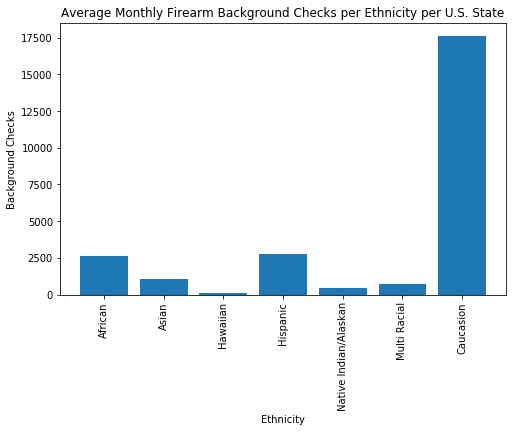

```python
plt.subplots(figsize=(8, 5))
locations = [1, 2, 3, 4, 5, 6, 7]
heights = [african, asian, hawaiian, hispanic, native_a, two_plus, white]
labels = ['African', 'Asian', 'Hawaiian', 'Hispanic', 'Native Indian/Alaskan', 'Multi Racial', 'Caucasion']
plt.bar(locations, heights, tick_label=labels)
plt.xticks(rotation=90)
plt.title('Average Monthly Firearm Background Checks per Ethnicity per U.S. State')
plt.xlabel('Ethnicity')
plt.ylabel('Background Checks');
```

Bar chart shows the mean number of firearm background checks performed per ethnicity per state per month in the U.S.

### Research Question 2: How many firearm background checks are performed per education level within the U.S.?

```python
diploma = census['high_school_graduate_or_higher'].mean()*bg_checks_mean
bachelors = census["bachelor's_degree_or_higher"].mean()*bg_checks_mean
```

The variables were created by multiplying the mean proportion of each degree for all states by the mean number of background checks performed per state per month in the U.S.

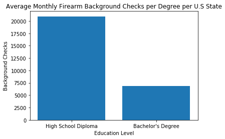

```python
locations = [1, 2]
heights = [diploma, bachelors]
labels = ['High School Diploma', "Bachelor's Degree"]
plt.bar(locations, heights, tick_label=labels)
#plt.xticks(rotation=90)
plt.title('Average Monthly Firearm Background Checks per Degree per U.S State')
plt.xlabel('Education Level')
plt.ylabel('Background Checks');
```

Bar chart shows the mean number of firearm background checks performed per education level per month in the U.S.

### Research Question 3: Is there a correlation between gun background checks compared to the percentage of people in poverty?

```python
state_checks = gun.loc[:, ['state', 'totals']].groupby('state').mean()
state_checks.head()
```

| state | totals |
| --- | --- |
| Alabama | 29542.198238 |
| Alaska | 5011.643172 |
| Arizona | 19496.537445 |
| Arkansas | 16531.422907 |
| California | 83762.392070 |

A groupby function was performed to get the necessary data for the next analysis. These give the average number of permits sold in each individual state per month in the U.S.

```python
merged = pd.merge(state_checks, census, on='state', how='inner')
merged.head()
```

|  | state | totals | population_estimates | black_or_african_american_alone | american_indian_and_alaska_native_alone | asian_alone | native_hawaiian_and_other_pacific_islander_alone | two_or_more_races | hispanic_or_latino | white_alone_mean | high_school_graduate_or_higher | bachelor's_degree_or_higher | persons_in_poverty |
| --- | --- | --- | --- | --- | --- | --- | --- | --- | --- | --- | --- | --- | --- |
| 0 | Alabama | 29542.198238 | 4863300 | 0.268 | 0.007 | 0.014 | 0.001 | 0.016 | 0.042 | 0.6755 | 0.843 | 0.235 | 0.171 |
| 1 | Alaska | 5011.643172 | 741894 | 0.038 | 0.152 | 0.063 | 0.013 | 0.073 | 0.070 | 0.6365 | 0.921 | 0.280 | 0.099 |
| 2 | Arizona | 19496.537445 | 6931071 | 0.049 | 0.054 | 0.034 | 0.003 | 0.028 | 0.309 | 0.6940 | 0.860 | 0.275 | 0.164 |
| 3 | Arkansas | 16531.422907 | 2988248 | 0.157 | 0.010 | 0.016 | 0.003 | 0.020 | 0.073 | 0.7615 | 0.848 | 0.211 | 0.172 |
| 4 | California | 83762.392070 | 39250017 | 0.065 | 0.017 | 0.148 | 0.005 | 0.038 | 0.389 | 0.5520 | 0.818 | 0.314 | 0.143 |

An inner merge was performed on the 'state' column to make analysis easier.

```python
state_checks_mean = census['persons_in_poverty']*merged['totals']
percent_poverty = census['persons_in_poverty']*100
```

Two variables were created.

The first was by multiplying the proportion of persons in poverty in each state by the average number of background checks performed in the same state.

The second variable was created by multiplying the proportion of people in poverty by 100 to get a percentage of poverty in each individual state.

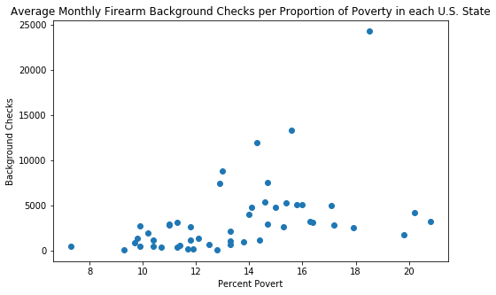

```python
plt.subplots(figsize=(8, 5))
plt.scatter(percent_poverty, state_checks_mean)
plt.title('Average Monthly Firearm Background Checks per Proportion of Poverty in each U.S. State')
plt.xlabel('Percent Povert')
plt.ylabel('Background Checks');
```

```python
merged.sort_values(by=['totals', 'persons_in_poverty'], ascending=False).head()
```

|  | state | totals | population_estimates | black_or_african_american_alone | american_indian_and_alaska_native_alone | asian_alone | native_hawaiian_and_other_pacific_islander_alone | two_or_more_races | hispanic_or_latino | white_alone_mean | high_school_graduate_or_higher | bachelor's_degree_or_higher | persons_in_poverty |
| --- | --- | --- | --- | --- | --- | --- | --- | --- | --- | --- | --- | --- | --- |
| 16 | Kentucky | 131112.044053 | 4436974 | 0.083 | 0.003 | 0.015 | 0.001 | 0.019 | 0.035 | 0.8650 | 0.842 | 0.223 | 0.185 |
| 42 | Texas | 85617.559471 | 27862596 | 0.126 | 0.010 | 0.048 | 0.001 | 0.019 | 0.391 | 0.6100 | 0.819 | 0.276 | 0.156 |
| 4 | California | 83762.392070 | 39250017 | 0.065 | 0.017 | 0.148 | 0.005 | 0.038 | 0.389 | 0.5520 | 0.818 | 0.314 | 0.143 |
| 12 | Illinois | 68156.537445 | 12801539 | 0.147 | 0.006 | 0.055 | 0.001 | 0.019 | 0.170 | 0.6945 | 0.879 | 0.323 | 0.130 |
| 37 | Pennsylvania | 57858.484581 | 12784227 | 0.118 | 0.004 | 0.035 | 0.001 | 0.019 | 0.070 | 0.7970 | 0.892 | 0.286 | 0.129 |

It looks like Kentucky is the major outlier in this chart.

### Research Question 4: Which states have the highest growth of firearm background checks within the data time period?

```python
years_sum = gun.groupby(['state', 'year'])['totals'].sum().reset_index()
years_sum.head()
```

|  | state | year | totals |
| --- | --- | --- | --- |
| 0 | Alabama | 1998 | 36568 |
| 1 | Alabama | 1999 | 246756 |
| 2 | Alabama | 2000 | 221911 |
| 3 | Alabama | 2001 | 230187 |
| 4 | Alabama | 2002 | 221008 |

The monthly background checks were summed to get the total for each year.

```python
checks_99 = years_sum.query('year == 1999')
checks_16 = years_sum.query('year == 2016')
```

The years 1999 and 2016 were filtered used because they had complete monthly data.

```python
diff = (checks_16.set_index('state')-checks_99.set_index('state')).dropna(axis=0)
diff.head()
```

| state | year | totals |
| --- | --- | --- |
| Alabama | 17 | 370191 |
| Alaska | 17 | 44574 |
| Arizona | 17 | 242731 |
| Arkansas | 17 | 81398 |
| California | 17 | 1494023 |

The difference was achieved by subtracting the 1999 data from the 2016 data.

```python
diff = diff.reset_index(drop = False)
```

The index numbers were reset after previous queries.

```python
top_five = diff.sort_values(by=['totals'], ascending=False).head()
top_five
```

|  | state | year | totals |
| --- | --- | --- | --- |
| 16 | Kentucky | 17 | 3428635 |
| 4 | California | 17 | 1494023 |
| 12 | Illinois | 17 | 1439222 |
| 13 | Indiana | 17 | 1233543 |
| 8 | Florida | 17 | 1155640 |

States were sorted in descending order based on totals.

```python
top_five = top_five.iloc[0:5, [0, 2]]
top_five
```

|  | state | totals |
| --- | --- | --- |
| 16 | Kentucky | 3428635 |
| 4 | California | 1494023 |
| 12 | Illinois | 1439222 |
| 13 | Indiana | 1233543 |
| 8 | Florida | 1155640 |

The top five states were filtered out.

```python
Kentucky = top_five.iloc[0, 1]
California = top_five.iloc[1, 1]
Illinois = top_five.iloc[2, 1]
Indiana = top_five.iloc[3, 1]
Florida = top_five.iloc[4, 1]
```

Variables were created for each of the top 5 states.

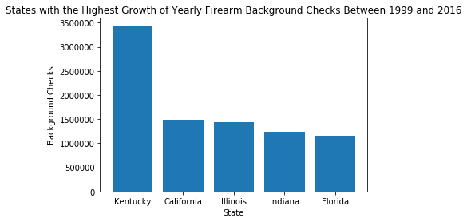

```python
locations = [1, 2, 3, 4, 5]
heights = [Kentucky, California, Illinois, Indiana, Florida]
labels = ['Kentucky', 'California', 'Illinois', 'Indiana', 'Florida']
plt.bar(locations, heights, tick_label=labels)
plt.title('States with the Highest Growth of Yearly Firearm Background Checks Between 1999 and 2016')
plt.xlabel('State')
plt.ylabel('Background Checks');
```

Bar chart shows the states with the highest growth of firearm background checks between 1999 and 2016.

### Research Question 5: What is the overall trend of firearm background checks thoughout the data time period.

```python
time_years = years_sum.iloc[1:19, :].groupby('year')['totals'].sum().reset_index()
time_years.head()
```

|  | year | totals |
| --- | --- | --- |
| 0 | 1999 | 246756 |
| 1 | 2000 | 221911 |
| 2 | 2001 | 230187 |
| 3 | 2002 | 221008 |
| 4 | 2003 | 225479 |

```python
year = time_years['year']
year_total = time_years['totals']
```

Variables were created for the year and the total number of background checks for that year.

[figure not shown]

```python
plt.subplots(figsize=(8, 5))
plt.plot(year, year_total)
plt.title('Average Number of Firearm Background Checks Per Year Between 1999-2016 in the U.S')
plt.xlabel('Year')
plt.ylabel('Background Checks')
plt.locator_params(nbins=11)
```

## Conclusions

How many firearm background checks are performed by each ethnicity within the U.S.?

The chart shows that caucasion americans produce the most firearm background checks of all ethnicities in the United States at approximately 17,500 checks per month per state. However, this implies that all ethnicities undergo firearm background checks in the same proportions that they are present in the United States. This assumption may lead to innacurate results in the analysis. Some ethnicities may be more prone to private gun sales over public, or vice versa.

How many firearm background checks are performed by different education levels in the U.S.?

The chart shows that people with high school diplomas produce more firearm background checks than those holding a Bachelor's Degree, with approximately 21,000 checks per month per state. Again, this implies that the different education levels undergo gun background checks in the same proportions that they are present in the United States. This is a limitation in the analysis.

Is there a correlation between firearm background checks compared to the percentage of people in poverty?

According the scatter plot, there is a positive correlation to the percentage of poverty to the number of monthly firearm background checks performed per state. The states with the higher rates of poverty tend to have the higher rates of firearm background checks performed. A major outlier in this plot is Kentucky. A possible explanation for this may be found from an article printed by WFPL in 2015 that states:

```
"one reason Kentucky reports such a high number of checks annually — more than double the number of Texas and California combined so far this year — is a policy that requires automatic monthly background checks on every holder of concealed-carry permits in the commonwealth." The article can be found on the wfpl website https://wfpl.org/kentucky-background-checks-stand-out/
```

Which states have the highest growth of firearm background checks within the data time period?

The graph shows that Kentucky has the highest growth of firearm background checks for all the states in the U.S. at approximately 3.5 million firearms background checks since 1999. The previously mentioned article which states that the state of Kentucky rechecks concealed carry permit holders on a monthly basis may be a reason why Kentucky has more than twice the firearm checks compared to California, at approximately 1.5 million.

```python
from subprocess import call
call(['python', '-m', 'nbconvert', 'Investigate_a_Dataset.ipynb'])
```

```
0
```